# BCB420H1 Winter 2026 - Assignment 1

Dataset Selection, Preprocessing, and Differential Expression Analysis of Bulk RNA-Seq Data of Aplastic Anemia and Healthy Donors

Sophia Li

2026-02-10

# 1 Introduction

Aplastic anemia (AA) is a rare and severe hematologic disorder characterized by bone marrow failure and pancytopenia which causes deficiency of all blood cell types. Patients commonly experiences fatigue, frequent infections, and bleeding tendencies due to the lack of sufficient blood cells, where severity varies depending on the extent of marrow failure. AA can arise from autoimmune-mediated destruction of hematopoietic stem cells, exposure to chemicals or drugs, radiation, or inherited genetic defects. It is a rare condition, with an estimated incidence of 1-2 cases per million people annually in most populations (Young 2018).

Studying AA through gene expression analysis allows researchers to investigate the molecular mechanisms underlying stem cell dysfunction and immune-mediated marrow suppression (Hrdlickova et al. 2016). Identifying differentially expressed genes between AA patients and healthy controls can reveal pathways relevant to disease pathogenesis and potential therapeutic targets (Zhu et al. 2021).

A recent study by Zhu et al. used single-cell transcriptomics to dissect the molecular landscape of hematopoietic stem and progenitor cells (HSPCs) and T cells in patients with AA. The authors aimed to characterize lineage-specific gene expression alterations and transcriptional regulatory networks in residual HSPCs from AA patients and healthy controls at single-cell resolution. Included in this study was three primary data sets corresponding to full-length RNA-seq, 3’ RNA-seq, and bulk RNA-seq of patients with severe (SAA) and non-severe aplastic anemia (non-SAA) and healthy donors. The study focused their analysis on the scRNA-seq datasets, whereas the bulk RNA-seq dataset was used for validation (Zhu et al. 2021).

In this work, we will focus our analysis on their bulk RNA-seq validation dataset and extend their investigation into expression patterns of non-SAA patients.

# 2 Dataset Retrieval

## 2.1 Data Information

The three datasets acquired and analyzed by Zhu et al. are openly available on the National Center of Biotechnology Information (NCBI)’s Gene Expression Omnibus (GEO) platform under the SuperSeries “Transcriptome analysis of HSPCs and T cells from aplastic anemia (AA) and healthy donors” (GSE145669). We will focus on the SubSeries “Bulk RNA-seq of aplastic anemia (AA) and healthy donors” (GSE165870) (Barrett et al. 2013; Zhu et al. 2021).

This dataset presents raw unnormalized counts data of Lin-CD34+ hematopoietic stem and progenitor cells derived from bone marrow of healthy donors and untreated non-severe aplastic anemia (non-SAA) patients. Clean reads were aligned against the human GRCh38 genome using STAR and gene quantification was performed using HTSeq. Three controls and six non-SAA samples are included in the dataset for a total of nine samples (Zhu et al. 2021).

## 2.2 Data Acquisition

To begin our analysis, we must first import all relevant packages. The `GEOquery` (Davis and Meltzer 2007) package will be used to retrieve the dataset from the GEO database; `biomaRt` (Durinck et al. 2005) to map identifiers; `DESeq2` (DeLuca et al. 2012), `SummarizedExperiment` (Morgan et al. 2025), and `limma` (Ritchie et al. 2015) for principal component analysis (PCA); `edgeR` (Chen et al. 2025) for differential expression analysis; `ggplot2` (Wickham 2016), `ggrepel` (Slowikowski 2024), `pheatmap` (Kolde 2025), `circlize` (Gu et al. 2014), and `ComplexHeatmap` (Gu et al. 2016) for visualizations; and `tidyr` (Wickham et al. 2024), `dplyr` (Wickham et al. 2023), and `knitr` (Xie 2014) for general data manipulation.

```r
library(biomaRt)
library(circlize)
library(ComplexHeatmap)
library(DESeq2)
library(dplyr)
library(edgeR)
library(GEOquery)
library(ggplot2)
library(ggrepel)
library(knitr)
library(limma)
library(pheatmap)
library(SummarizedExperiment)
library(tidyr)
```

We use the `GEOquery` (Davis and Meltzer 2007) package to fetch the experimental metadata available and inspect the summary as provided. From the results, we confirm that we have accessed the correct experiment.

```r
# Retrieve the experimental metadata from the `GEOquery` package
gse <- "GSE165870"
gse_data <- GEOquery::getGEO(gse, GSEMatrix = FALSE)

# Inspect the summary as provided
gse_data@header$summary
```

```
## [1] "Bulk RNA-seq data of  Lin-CD34+ hematopoietic stem and progenitor cells derived from bone marrow of healthy donors and untreated aplastic anemia  patients"
```

Each dataset provided within the SuperSeries is associated with their own unique GSE Series identifier. For our dataset of interest, only the raw counts are provided. Thus, we can directly use the `GEOquery` (Davis and Meltzer 2007) package to download and read the counts matrix from the database. If the file was previously downloaded and exists at the path specified by the code below, it will be imported and loaded into memory.

```r
# Fetch the supplementary file's name; only one is provided
supplementary_files <- GEOquery::getGEOSuppFiles(gse, fetch_files = FALSE)
filename <- supplementary_files$fname[1]

# Download the file to the current path if not already found
download_dir <- file.path(getwd())
file_path = file.path(download_dir, gse, filename)

if (! file.exists(file_path)) {
  file <- GEOquery::getGEOSuppFiles(
    GEO          = gse,
    filter_regex = file_name,
    base_dir     = download_dir,
    fetch_files  = TRUE
  )
}

# Load the downloaded file as a data.frame
aa_data <- read.table(file_path, header = TRUE, check.names = TRUE)

cat("Successfully loaded the raw counts data with", ncol(aa_data[, 3:11]),
    "samples and", nrow(aa_data), "genes.")
```

```
## Successfully loaded the raw counts data with 9 samples and 20234 genes.
```

The dataset contains 20234 genes and nine samples, where both Ensembl gene identifiers (`GeneName`) and gene symbols (`GeneSymbol`) are provided. Furthermore, disease state is indicated in the column names of each sample, where the `Ctrl` prefix denotes healthy donors, and `P` denotes an AA sample (Zhu et al. 2021). To verify these mappings, we will manually inspect the metadata in the following subsection.

The experimental design metadata available through GEO designate this dataset as raw counts and do not reference further cleaning, filtering, or normalizing steps (Zhu et al. 2021; Barrett et al. 2013). Furthermore, the methodology outlined in the paper does not detail the exact protocol used to prepare the bulk RNA-seq data when it was used to validate their scRNA-seq findings (Zhu et al. 2021).

## 2.3 Metadata Extraction

Sample metadata is additionally provided by the GEO database and provides information such as disease state, age, and canonical GSM Sample identifiers (Barrett et al. 2013). The `GEOquery` (Davis and Meltzer 2007) package is similarly used to retrieve this data and basic string manipulation is used to clean the values to reduce redundancy.

```r
# Extract sample metadata from the GEOquery results object
metadata <- gse_data@gsms
sample_group <- do.call(rbind, lapply(metadata, FUN = function(x) {
  c(x@header$title, x@header$characteristics_ch1)
}))

# Convert sample metadata into a data.frame
metadata <- as.data.frame(sample_group, stringsAsFactors = FALSE)

# Clean the row and column names to align with the counts data
colnames(metadata) <- c('sample', 'sex', 'disease_state',
                        'surface_markers', 'tissue', 'age')
rownames(metadata) <- metadata$sample

#Remove column prefixes to improve readibility and reduce redundancy
metadata[, 'sex']             <- gsub(x           = metadata[, 'sex'],
                                      pattern     = 'Sex: ',
                                      replacement = '')
metadata[, 'disease_state']   <- gsub(x           = metadata[, 'disease_state'],
                                      pattern     = 'disease state: ',
                                      replacement = '')
metadata[, 'surface_markers'] <- gsub(x           = metadata[, 'surface_markers'],
                                      pattern     = 'surface markers: ',
                                      replacement = '')
metadata[, 'tissue']          <- gsub(x           = metadata[, 'tissue'],
                                      pattern     = 'tissue: ',
                                      replacement = '')
metadata[, 'age']             <- gsub(x           = metadata[, 'age'],
                                      pattern     = 'age: ',
                                      replacement = '')

knitr::kable(metadata, caption = "**Table 1:** Sample metadata retrieved from GEO using the `GEOquery` package. Metadata includes disease state, sex, age, tissue source, and surface markers for each sample. String processing was applied to remove redundant prefixes.")
```

**Table 1:** Sample metadata retrieved from GEO using the `GEOquery` package. Metadata includes disease state, sex, age, tissue source, and surface markers for each sample. String processing was applied to remove redundant prefixes.

|  | sample | sex | disease_state | surface_markers | tissue | age |
| --- | --- | --- | --- | --- | --- | --- |
| Ctrl2 | Ctrl2 | male | Ctrl | Lin-CD34+ | Bone Marrow | 38 |
| Ctrl7 | Ctrl7 | female | Ctrl | Lin-CD34+ | Bone Marrow | 41 |
| Ctrl8 | Ctrl8 | female | Ctrl | Lin-CD34+ | Bone Marrow | 44 |
| P18 | P18 | female | non-SAA | Lin-CD34+ | Bone Marrow | 50 |
| P19 | P19 | male | non-SAA | Lin-CD34+ | Bone Marrow | 47 |
| P20 | P20 | male | non-SAA | Lin-CD34+ | Bone Marrow | 66 |
| P21 | P21 | female | non-SAA | Lin-CD34+ | Bone Marrow | 40 |
| P22 | P22 | male | non-SAA | Lin-CD34+ | Bone Marrow | 32 |
| P23 | P23 | female | non-SAA | Lin-CD34+ | Bone Marrow | 33 |

Referencing the metadata, we confirm that sample name prefixes correspond to disease state and that all samples are extracted from Lin -CD34++ hematopoietic stem and progenitor cells derived from bone marrow tissue (Zhu et al. 2021). We will use the `disease_state` column as canonical group membership, rather than sample name prefixes, for downstream analysis.

```r
# Clean up intermediate objects
rm(gse_data, sample_group, supplementary_files, download_dir, file_path,
   filename, gse)
```

# 3 Data Cleaning

The dataset we have fetched has provided raw counts data, thus we must perform several steps of cleaning, filtering, and evaluation before we proceed with differential expression analysis. First, we must begin by parsing the raw counts and metadata dataframes into a standardized format.

## 3.1 Table Parsing

Standardized naming conventions is crucial for maintaining well-documented and human-readable code. Thus, we will begin our cleaning by normalizing the column names of the raw counts dataframe to pot-hole style to align with the metadata. Note that we will leave the sample names as-is to align with their corresponding metadata entries. Furthermore, we will set the Ensembl gene identifiers as the rownames to support downstream manipulations.

```r
# Rename the data columns into pot-hole style
aa_data <- dplyr::rename(aa_data, gene_id = GeneName, gene_symbol = GeneSymbol)
rownames(aa_data) <- aa_data$gene_id
knitr::kable(head(aa_data), caption = "**Table 2:** Raw counts data standardized for human-readable naming conventions (`gene_id` and `gene_symbol`) to align with metadata, with Ensembl gene identifiers set as rownames to facilitate downstream analysis. Sample column names were left unchanged to maintain correspondence with metadata entries.")
```

**Table 2:** Raw counts data standardized for human-readable naming conventions (`gene_id` and `gene_symbol`) to align with metadata, with Ensembl gene identifiers set as rownames to facilitate downstream analysis. Sample column names were left unchanged to maintain correspondence with metadata entries.

|  | gene_id | gene_symbol | Ctrl2 | Ctrl7 | Ctrl8 | P18 | P19 | P20 | P21 | P22 | P23 |
| --- | --- | --- | --- | --- | --- | --- | --- | --- | --- | --- | --- |
| ENSG00000000003.14 | ENSG00000000003.14 | TSPAN6 | 196 | 5 | 68 | 0 | 0 | 0 | 0 | 82 | 0 |
| ENSG00000000005.5 | ENSG00000000005.5 | TNMD | 0 | 0 | 0 | 0 | 0 | 0 | 0 | 0 | 0 |
| ENSG00000000419.12 | ENSG00000000419.12 | DPM1 | 684 | 8 | 123 | 34 | 103 | 116 | 421 | 67 | 123 |
| ENSG00000000457.13 | ENSG00000000457.13 | SCYL3 | 48 | 1 | 52 | 1 | 23 | 22 | 69 | 33 | 13 |
| ENSG00000000460.16 | ENSG00000000460.16 | C1orf112 | 20 | 2 | 19 | 11 | 6 | 2 | 17 | 57 | 2 |
| ENSG00000000938.12 | ENSG00000000938.12 | FGR | 163 | 20 | 29 | 71 | 24 | 101 | 38 | 0 | 114 |

## 3.2 Removing Lowly Expressed Genes

With the parsed dataset, we can now consider if removing lowly expressed genes is needed. The Zhu et al. paper did not specify whether or not lowly expressed genes were removed, nor any related thresholds used for filtering. More broadly, exact methodology on how the bulk RNA-seq dataset was cleaned was neither mentioned in the original publication, supplementary information, or GEO experimental design metadata (Zhu et al. 2021’; Barrett et al. 2013).

Removing lowly expressed genes is important because genes with consistently low counts across many samples contribute mostly technical noise, violate assumptions of count-based differential expression models, and increase the multiple testing burden. However, low counts are not inherently problematic. For example, a gene only being expressed in one condition may be biologically meaningful, but genes undetected in most samples add little signal (Conesa et al. 2016; Sha et al. 2015a).

Therefore, we must analyze the distribution of raw counts to guide filtering and will remove genes not expressed in at least three samples, corresponding to the size of our smallest disease group, before proceeding with downstream quality control analysis.

### 3.2.1 Distribution Analysis

We begin with a preliminary assessment of the count distribution to characterize sample-level expression profiles and evaluate the impact of filtering lowly expressed genes. Specifically, per-sample summary statistics, including the minimum, maximum, mean, and interquartile range (IQR), are computed to assess distributional properties prior to downstream quality control and differential expression analysis.

```r
# Summarize per-sample distributions
raw_counts <- aa_data[3:11]
knitr::kable(
  data.frame(do.call(cbind, lapply(raw_counts, summary))),
  caption = "**Table 3:** Summary statistics of raw gene counts per sample, including minimum, first quartile, median, mean, third quartile, and maximum. Many genes have zero or low counts, highlighting the prevalence of lowly expressed genes and providing a baseline for filtering decisions.")
```

**Table 3:** Summary statistics of raw gene counts per sample, including minimum, first quartile, median, mean, third quartile, and maximum. Many genes have zero or low counts, highlighting the prevalence of lowly expressed genes and providing a baseline for filtering decisions.

|  | Ctrl2 | Ctrl7 | Ctrl8 | P18 | P19 | P20 | P21 | P22 | P23 |
| --- | --- | --- | --- | --- | --- | --- | --- | --- | --- |
| Min. | 0.0000 | 0.0000 | 0.0000 | 0.0000 | 0.00000 | 0.0000 | 0.0 | 0.0000 | 0.00000 |
| 1st Qu. | 0.0000 | 0.0000 | 0.0000 | 0.0000 | 0.00000 | 0.0000 | 0.0 | 0.0000 | 0.00000 |
| Median | 22.0000 | 2.0000 | 13.0000 | 8.0000 | 4.00000 | 10.0000 | 7.0 | 6.0000 | 9.00000 |
| Mean | 291.4766 | 27.9272 | 103.4913 | 111.0755 | 78.26638 | 104.0326 | 198.3 | 188.7041 | 98.18242 |
| 3rd Qu. | 227.0000 | 13.0000 | 99.0000 | 81.7500 | 71.00000 | 85.0000 | 108.0 | 177.0000 | 86.00000 |
| Max. | 72376.0000 | 4646.0000 | 18615.0000 | 51972.0000 | 10245.00000 | 63484.0000 | 92134.0 | 53419.0000 | 16192.00000 |

Across all samples, the minimum and first quartile of the gene-level count distributions are zero, indicating that a substantial fraction of genes are either unexpressed or expressed at very low levels. A density plot further visualizes the distribution of log10-transformed counts across samples.

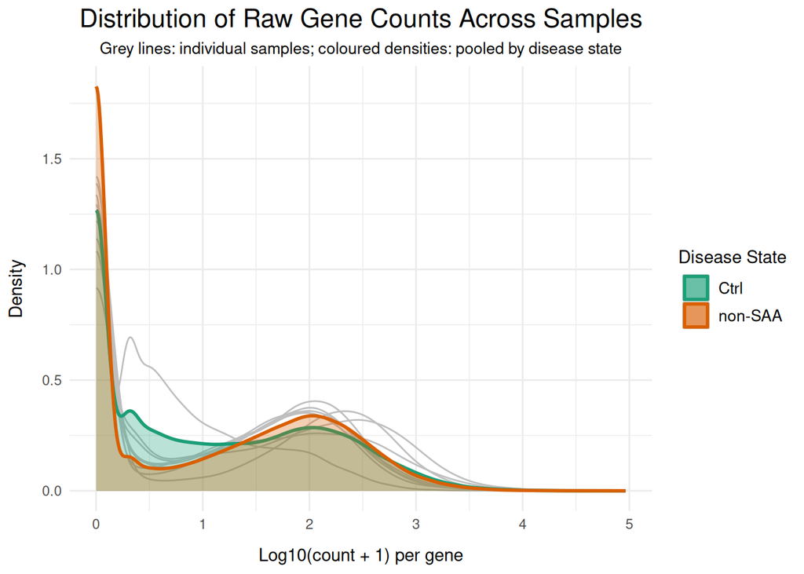

**Figure 1:** Distribution of log10-transformed gene-level counts across samples. Grey lines represent individual sample densities; coloured densities show pooled distributions by disease state (green: healthy controls; orange: non-SAA). Many genes are unexpressed or lowly expressed, while overall expression patterns are consistent within disease groups, supporting subsequent filtering and normalization steps.

```r
# Convert the raw counts to a long format
counts_long <- raw_counts %>%
  mutate(gene_id = rownames(raw_counts)) %>%
  tidyr::pivot_longer(-gene_id, names_to = "sample", values_to = "counts") %>%
  left_join(metadata[, c("sample", "disease_state")], by = "sample") %>%
  mutate(log_count = log10(counts + 1))

# Assign distinct colours for each disease state (healthy vs non-SAA)
disease_state_colours <- c("Ctrl" = "#1b9e77", "non-SAA" = "#d95f02")

# Visualize the counts distribution as a density plot
ggplot2::ggplot() +
  ggplot2::geom_density(data = counts_long, color = "grey", alpha = 0.5,
                        ggplot2::aes(x = log_count, group = sample)) +
  ggplot2::geom_density(data = counts_long, alpha = 0.3, size = 1,
                        ggplot2::aes(x = log_count, color = disease_state,
                                     fill = disease_state)) +
  ggplot2::scale_color_manual(name = "Disease State", values = disease_state_colours) +
  ggplot2::scale_fill_manual(name = "Disease State", values = disease_state_colours) +
  ggplot2::xlab("Log10(count + 1) per gene") +
  ggplot2::ylab("Density") +
  ggplot2::ggtitle(
    "Distribution of Raw Gene Counts Across Samples",
    subtitle = "Grey lines: individual samples; coloured densities: pooled by disease state") +
  ggplot2::theme_minimal(base_size = 11) +
  ggplot2::theme(
    axis.title.y = ggplot2::element_text(margin = ggplot2::margin(r = 10)),
    axis.title.x = ggplot2::element_text(margin = ggplot2::margin(t = 10)),
    legend.title = ggplot2::element_text(size = 11, hjust = 0.5),
    legend.text = ggplot2::element_text(size = 10),
    plot.title = ggplot2::element_text(size = 16, hjust = 0.5),
    plot.subtitle = ggplot2::element_text(size = 10, hjust = 0.5)
  )
```

The density plots show a pronounced peak at zero, reflecting the high prevalence of unexpressed or very lowly expressed genes, followed by a steep decline for moderately expressed genes. This pattern reinforces the rationale for filtering lowly expressed genes prior to downstream analyses, as these genes are unlikely to provide reliable signal and may contribute noise to differential expression testing (Conesa et al. 2016).

To complement the distributional assessment, we next examine gene detection across samples to determine how consistently each gene is expressed. This helps identify genes that are rarely detected or expressed in only a subset of samples, providing an additional criterion for filtering lowly expressed genes before downstream differential expression analysis (Conesa et al. 2016).

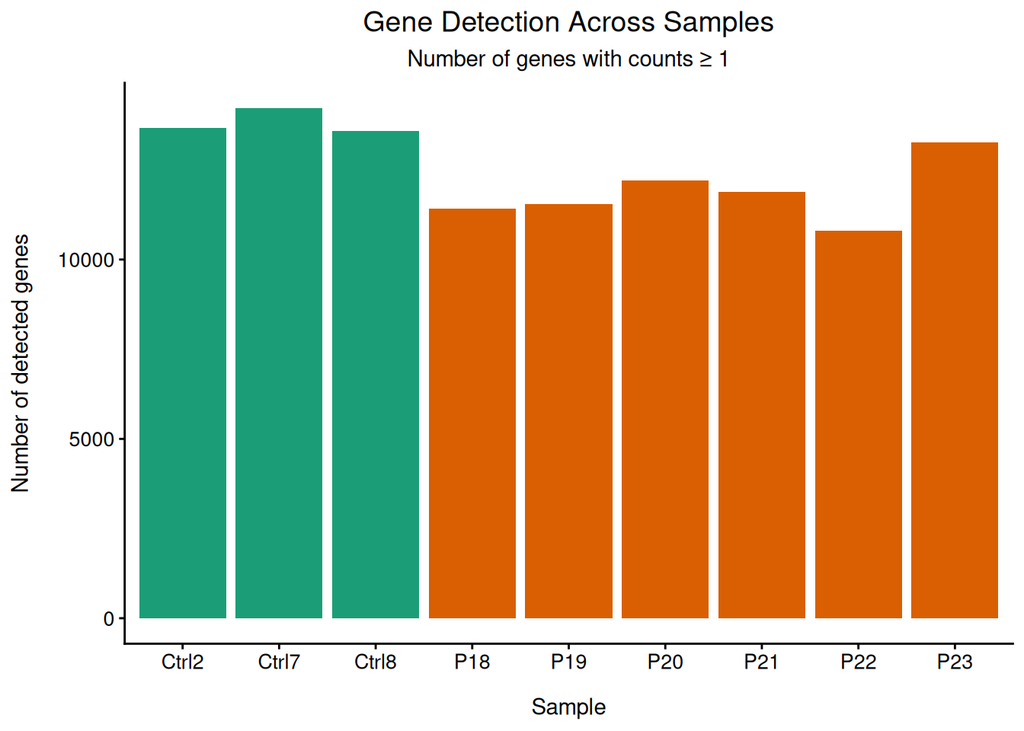

**Figure 2:** Number of genes detected per sample (counts ≥ 1). Bars are coloured by disease state (green: controls; orange: non-SAA). Most genes are consistently detected across samples (~12,000 genes), whereas a minority are unexpressed or detected in few samples, informing the selection of filtering thresholds prior to differential expression analysis.

```r
# Define detection as having at least one count
counts_long$detected <- counts_long$counts >= 1

# Summarize the number of detected genes per sample
gene_detection <- stats::aggregate(
  detected ~ sample,
  data = counts_long,
  FUN = sum
)

# Add disease state for colouring
gene_detection <- dplyr::left_join(
  gene_detection, metadata %>% dplyr::select(sample, disease_state),
  by = "sample"
)

# Visualize a barplot of genes detected per sample
ggplot2::ggplot(gene_detection, ggplot2::aes(x = sample, y = detected,
                                             fill = disease_state)) +
  ggplot2::geom_bar(stat = "identity") +
  ggplot2::scale_fill_manual(name = "Disease State", values = disease_state_colours) +
  ggplot2::labs(
      title = "Gene Detection Across Samples",
      subtitle = "Number of genes with counts ≥ 1",
      x = "Sample",
      y = "Number of detected genes"
  ) +
  ggplot2::theme_classic(base_size = 11) +
  ggplot2::theme(
      plot.title    = ggplot2::element_text(hjust = 0.5, size = 14),
      plot.subtitle = ggplot2::element_text(hjust = 0.5, size = 11),
      axis.title.x  = ggplot2::element_text(margin = ggplot2::margin(t = 12)),
      axis.title.y  = ggplot2::element_text(margin = ggplot2::margin(r = 12)),
      axis.text.x   = ggplot2::element_text(size = 10, hjust = 0.5),
      axis.text.y   = ggplot2::element_text(size = 10),
      legend.position = "none"
  )
```

Gene detection across samples is relatively consistent, with approximately 12000 genes detected per sample. This indicates that the majority of genes are expressed in multiple samples, while the remaining genes are largely unexpressed or detected in very few samples. Such consistency supports the use of a filtering threshold to remove lowly expressed genes prior to downstream differential expression analysis, minimizing noise while retaining reliably measured genes (Sha et al. 2015a).

Overall, our distributional assessment highlights a substantial fraction of unexpressed or lowly expressed genes, while gene detection is consistent across samples. These observations justify applying a threshold to filter lowly expressed genes before quality assessment, normalization, and differential expression analysis.

### 3.2.2 Gene Filtering

The `edgeR` (Chen et al. 2025) package is used to filter out genes with low expression, retaining only those expressed in at least three samples. Ensembl gene identifiers are used for filtering to ensure uniqueness, as gene symbols have not yet been validated.

```r
# Initialize a DGEList and the model design
dge <- edgeR::DGEList(counts = raw_counts, group = metadata$disease_state)
design <- stats::model.matrix(~ disease_state, data = metadata)

# Filter by expression using a minimum of three samples
keep <- edgeR::filterByExpr(dge, design)
filtered_dge <- dge[keep, , keep.lib.sizes = FALSE]

# Filter our original data object
aa_data <- aa_data[rownames(aa_data) %in% rownames(filtered_dge$counts), ]

# Evaluate the retention percentage
retention <- nrow(aa_data) / nrow(dge) * 100
cat("Retained", retention, "per cent of genes:",
    nrow(dge), "original,", nrow(aa_data), "result")
```

```
## Retained 54.27992 per cent of genes: 20234 original, 10983 result
```

Let us perform a final inspection of the summary statistics per sample post-removal.

```r
knitr::kable(
  data.frame(do.call(cbind, lapply(aa_data[3:11], summary))),
  caption = "**Table 4:** Summary statistics of gene counts per sample after removal of lowly expressed genes. While the minimum remains zero, the first quartile and mean have increased, reflecting the removal of low-count genes and resulting in a dataset with higher overall expression levels and reduced technical noise."
)
```

**Table 4:** Summary statistics of gene counts per sample after removal of lowly expressed genes. While the minimum remains zero, the first quartile and mean have increased, reflecting the removal of low-count genes and resulting in a dataset with higher overall expression levels and reduced technical noise.

|  | Ctrl2 | Ctrl7 | Ctrl8 | P18 | P19 | P20 | P21 | P22 | P23 |
| --- | --- | --- | --- | --- | --- | --- | --- | --- | --- |
| Min. | 0.0000 | 0.00000 | 0.0000 | 0.0000 | 0.0000 | 0.0000 | 0.0000 | 0.000 | 0.0000 |
| 1st Qu. | 62.5000 | 3.00000 | 34.0000 | 21.0000 | 19.0000 | 28.0000 | 22.0000 | 45.000 | 25.0000 |
| Median | 195.0000 | 10.00000 | 88.0000 | 70.0000 | 62.0000 | 74.0000 | 90.0000 | 154.000 | 75.0000 |
| Mean | 534.2796 | 49.85514 | 189.2067 | 202.2112 | 143.4701 | 190.8182 | 364.3203 | 345.393 | 179.8384 |
| 3rd Qu. | 515.0000 | 43.00000 | 190.0000 | 175.0000 | 150.0000 | 171.0000 | 302.0000 | 365.000 | 181.0000 |
| Max. | 72376.0000 | 4646.00000 | 18615.0000 | 51972.0000 | 10245.0000 | 63484.0000 | 92134.0000 | 53419.000 | 16192.0000 |

After filtering lowly expressed genes, the minimum count remains zero, but the first quartile and mean have increased substantially. This reflects the removal of many low-count genes, resulting in a dataset with higher overall expression levels and reduced technical noise, which is more suitable for downstream differential expression analysis (Conesa et al. 2016).

Now that we have successfully removed lowly expressed genes from our dataset, we can proceed with further cleaning and downstream analysis.

```r
# Clean intermediate objects; we'll keep design for later
rm(dge, filtered_dge, gene_detection, counts_long, raw_counts, colours, keep,
   retention)
```

## 3.3 Identifier Mapping

Although gene symbols are provided in the dataset, no documentation on how they were generated or validated is available. To ensure consistency with current HGNC annotations and account for possible outdated aliases or removed entries, all genes will be remapped using the `biomaRt` (Durinck et al. 2005) package (Durinck et al. 2009).

```r
# Drop the provided gene symbols to remap them to ensure consistency
aa_data$gene_symbol <- NULL

# Strip Ensembl version suffixes
strip_ensembl_version <- function(ids) { sub("\\.\\d+$", "", ids) }
ensembl_ids <- unique(strip_ensembl_version(aa_data$gene_id))

# Retrieve current HGNC mappings
ensembl <- biomaRt::useMart(
  "ensembl",
  dataset = "hsapiens_gene_ensembl",
  host = "https://www.ensembl.org"
)
map <- biomaRt::getBM(
  attributes = c("ensembl_gene_id", "hgnc_symbol"),
  filters = "ensembl_gene_id",
  values = ensembl_ids,
  mart = ensembl
)

# Join the mapping to the original data
aa_data <- aa_data %>%
  mutate(ensembl_gene_id = strip_ensembl_version(.data$gene_id)) %>%
  left_join(map, by = "ensembl_gene_id") %>%
  dplyr::rename(gene_symbol = hgnc_symbol) %>%
  dplyr::select(gene_id, gene_symbol, everything())

knitr::kable(
  head(aa_data),
  caption = "**Table 5:** Remapping of Ensembl gene identifiers to current HGNC symbols. Original gene symbols were removed to ensure consistency and alignment with current annotations, and Ensembl version suffixes were stripped prior to mapping. The resulting `gene_symbol` column reflects updated, standardized gene names suitable for downstream analyses and consistent cross-referencing with public databases."
)
```

**Table 5:** Remapping of Ensembl gene identifiers to current HGNC symbols. Original gene symbols were removed to ensure consistency and alignment with current annotations, and Ensembl version suffixes were stripped prior to mapping. The resulting `gene_symbol` column reflects updated, standardized gene names suitable for downstream analyses and consistent cross-referencing with public databases.

| gene_id | gene_symbol | Ctrl2 | Ctrl7 | Ctrl8 | P18 | P19 | P20 | P21 | P22 | P23 | ensembl_gene_id |
| --- | --- | --- | --- | --- | --- | --- | --- | --- | --- | --- | --- |
| ENSG00000000003.14 | TSPAN6 | 196 | 5 | 68 | 0 | 0 | 0 | 0 | 82 | 0 | ENSG00000000003 |
| ENSG00000000419.12 | DPM1 | 684 | 8 | 123 | 34 | 103 | 116 | 421 | 67 | 123 | ENSG00000000419 |
| ENSG00000000457.13 | SCYL3 | 48 | 1 | 52 | 1 | 23 | 22 | 69 | 33 | 13 | ENSG00000000457 |
| ENSG00000000460.16 | FIRRM | 20 | 2 | 19 | 11 | 6 | 2 | 17 | 57 | 2 | ENSG00000000460 |
| ENSG00000000938.12 | FGR | 163 | 20 | 29 | 71 | 24 | 101 | 38 | 0 | 114 | ENSG00000000938 |
| ENSG00000000971.15 | CFH | 351 | 1 | 107 | 0 | 2 | 2 | 6 | 3 | 27 | ENSG00000000971 |

The mapping is summarized to assess whether all Ensembl gene identifiers were successfully assigned an HGNC symbol and to identify any cases of multi-mapped symbols.

```r
# Summarize the total number of Ensembl gene IDs that were able to be mapped
n_ensembl_total <- aa_data %>% distinct(gene_id) %>% nrow()
n_mapped <- aa_data %>% filter(! is.na(gene_symbol), gene_symbol != "") %>%
  distinct(gene_id) %>% nrow()
n_unmapped <- n_ensembl_total - n_mapped

# Summarize duplicate mappings in Ensembl gene IDs and HGNC symbols
id_duplicates <- aa_data %>%
  group_by(gene_id) %>%
  summarize(n_hgnc = n_distinct(gene_symbol), .groups = "drop") %>%
  filter(n_hgnc > 1) %>%
  nrow()

symbol_duplicates <- aa_data %>%
  filter(! is.na(gene_symbol), gene_symbol != '') %>%
  group_by(gene_symbol) %>%
  summarize(n_ensembl = n_distinct(gene_id), .groups = "drop") %>%
  filter(n_ensembl > 1) %>%
  nrow()

# Summarize multi-mappings (rare)
multi_mapped <- aa_data %>%
  filter(! is.na(gene_symbol), grepl(";", gene_symbol)) %>%
  nrow()

# Visualize the results as a data.frame
knitr::kable(tibble::tibble(
  category = c("Total Ensembl Gene ID",
               "Total mapped gene ID",
               "Total unmapped gene ID",
               "Duplicate gene ID mappings",
               "Duplicate gene symbol mappings",
               "Multi-mapped gene symbols"),
  n        = c(n_ensembl_total,
               n_mapped,
               n_unmapped,
               id_duplicates,
               symbol_duplicates,
               multi_mapped),
  ), caption = "**Table 6:** Summary of Ensembl-to-HGNC gene identifier mapping."
)
```

**Table 6:** Summary of Ensembl-to-HGNC gene identifier mapping.

| category | n |
| --- | --- |
| Total Ensembl Gene ID | 10983 |
| Total mapped gene ID | 10956 |
| Total unmapped gene ID | 27 |
| Duplicate gene ID mappings | 0 |
| Duplicate gene symbol mappings | 0 |
| Multi-mapped gene symbols | 0 |

After remapping, no duplicate gene IDs, duplicate symbols, or multi-mapped entries were detected. However, 27 gene identifiers could not be mapped to a current HGNC symbol. To diagnose this, we evaluate common cases regarding the Ensembl gene identifier (Yates et al. 2026).

```r
# Identify unmapped Ensembl gene IDs with the version stripped
unmapped_ids <- aa_data %>%
  filter(is.na(gene_symbol) | gene_symbol == '') %>%
  mutate(gene_id = strip_ensembl_version(.data$gene_id)) %>%
  pull(gene_id) %>%
  unique()

# Diagnose the reason that mapping failed
unmapped <- tibble::tibble(id = unmapped_ids) %>%
  mutate(type = case_when(
    grepl("^ENSG\\d+$", id) ~ "Ensembl gene ID (ENSG)",
    grepl("^ENSG\\d+\\.\\d+$", id) ~ "Ensembl gene ID with version (ENSG.x) — needs stripping",
    grepl("^ENST\\d+", id) ~ "Ensembl transcript ID (ENST) — wrong target for gene mapping",
    grepl("^ENSP\\d+", id) ~ "Ensembl protein ID (ENSP) — wrong target",
    grepl("^ENS.*G\\d+", id) ~ "Non-human Ensembl gene (e.g., ENSMUSG...) — wrong organism",
    grepl("^ERCC-", id) ~ "ERCC spike-in control — not a gene",
    grepl("^MT-|^mt-", id) ~ "Mitochondrial gene symbol (not Ensembl ID) — different ID system",
    grepl("^\\d+$", id) ~ "Entrez Gene ID — different ID system",
    TRUE ~ "Other / unknown format"
  ))

knitr::kable(head(unmapped), caption = "**Table 7:** Classification of unmapped Ensembl gene identifiers.")
```

**Table 7:** Classification of unmapped Ensembl gene identifiers.

| id | type |
| --- | --- |
| ENSG00000112096 | Ensembl gene ID (ENSG) |
| ENSG00000116957 | Ensembl gene ID (ENSG) |
| ENSG00000130723 | Ensembl gene ID (ENSG) |
| ENSG00000133808 | Ensembl gene ID (ENSG) |
| ENSG00000145075 | Ensembl gene ID (ENSG) |
| ENSG00000148362 | Ensembl gene ID (ENSG) |

We confirm that all unmapped Ensembl gene identifiers were syntactically valid but either retired or deprecated in the current release. These entries will be retained but flagged as unmapped (`NA`).

We are expected to produce a matrix with gene symbols as rownames; however, as discussed on the course board, gene symbols should be left as `NA` when the corresponding Ensembl ID could not be mapped (Isserlin 2026). To maintain unique and non-empty row identifiers for downstream analysis, Ensembl IDs were used as a fallback for these unmapped genes while still preserving the NA annotation in the gene_symbol column (Yates et al. 2026; Durinck et al. 2009).

```r
# Create a column to use as rownames: HGNC if available, else Ensembl ID
aa_data <- aa_data %>%
  mutate(row_id = if_else(!is.na(gene_symbol) & gene_symbol != "",
                          gene_symbol, gene_id))

# Set rownames for expression matrices
rownames(aa_data) <- aa_data$row_id
aa_data$row_id <- NULL

# Drop the ensembl gene ID row made without version numbers
aa_data$ensembl_gene_id <- NULL

knitr::kable(
  head(aa_data),
  caption = "**Table 8:** Final gene annotation for the expression matrix. Row names were set to HGNC symbols where available; for genes without a mapped HGNC symbol, the Ensembl gene ID was used as a fallback while preserving `NA` in the `gene_symbol` column. This approach ensures unique, non-empty row identifiers for downstream analyses while retaining annotation information for unmapped genes."
)
```

**Table 8:** Final gene annotation for the expression matrix. Row names were set to HGNC symbols where available; for genes without a mapped HGNC symbol, the Ensembl gene ID was used as a fallback while preserving `NA` in the `gene_symbol` column. This approach ensures unique, non-empty row identifiers for downstream analyses while retaining annotation information for unmapped genes.

|  | gene_id | gene_symbol | Ctrl2 | Ctrl7 | Ctrl8 | P18 | P19 | P20 | P21 | P22 | P23 |
| --- | --- | --- | --- | --- | --- | --- | --- | --- | --- | --- | --- |
| TSPAN6 | ENSG00000000003.14 | TSPAN6 | 196 | 5 | 68 | 0 | 0 | 0 | 0 | 82 | 0 |
| DPM1 | ENSG00000000419.12 | DPM1 | 684 | 8 | 123 | 34 | 103 | 116 | 421 | 67 | 123 |
| SCYL3 | ENSG00000000457.13 | SCYL3 | 48 | 1 | 52 | 1 | 23 | 22 | 69 | 33 | 13 |
| FIRRM | ENSG00000000460.16 | FIRRM | 20 | 2 | 19 | 11 | 6 | 2 | 17 | 57 | 2 |
| FGR | ENSG00000000938.12 | FGR | 163 | 20 | 29 | 71 | 24 | 101 | 38 | 0 | 114 |
| CFH | ENSG00000000971.15 | CFH | 351 | 1 | 107 | 0 | 2 | 2 | 6 | 3 | 27 |

```r
# Clean up intermediate objects
rm(ensembl, expr_mapped, map, unmapped, ensembl_ids, id_duplicates,
   multi_mapped, n_ensembl_total, n_mapped, n_unmapped, symbol_duplicates,
   unmapped_ids, strip_ensembl_version)
```

## 3.4 Quality Assessment

Before normalization and outlier detection, it is essential to assess the quality of the raw count data (Isserlin 2026). Quality assessment identifies technical artifacts, sample-level biases, and abnormal distributions that could confound downstream analyses. Performing these checks prior to normalization ensures that observed differences are biologically meaningful rather than driven by low-quality samples or extreme counts, and that subsequent normalization and filtering steps are applied to a reliable dataset (Conesa et al. 2016).

### 3.4.1 Data Integrity

First, let us evaluate if any non-numeric or null values exist in our dataset.

```r
raw_counts <- aa_data[3:11]

# Assert that no non-numeric values exist in the data
is_numeric <- !all(sapply(raw_counts, is.numeric))

# Evaluate if any NAs exist in the data
is_missing <- any(is.na(raw_counts))

knitr::kable(tibble::tibble(
  category = c("Contains non-numeric values", "Contains missing values"),
  n        = c(is_numeric, is_missing)),
  caption = "**Table 9:** Data integrity check."
)
```

**Table 9:** Data integrity check.

| category | n |
| --- | --- |
| Contains non-numeric values | FALSE |
| Contains missing values | FALSE |

We confirm that no invalid values exist in our dataset, let us move on.

### 3.4.2 Library Size

Next, we will evaluate sequencing depth and overall coverage by quantifying the total number of reads per sample. Inspecting it helps identify samples with unusually low or high counts, which could bias normalization and differential expression analyses if left uncorrected (DeLuca et al. 2012). We will use a barplot to visualize library size per sample and identify potential outliers in our dataset.

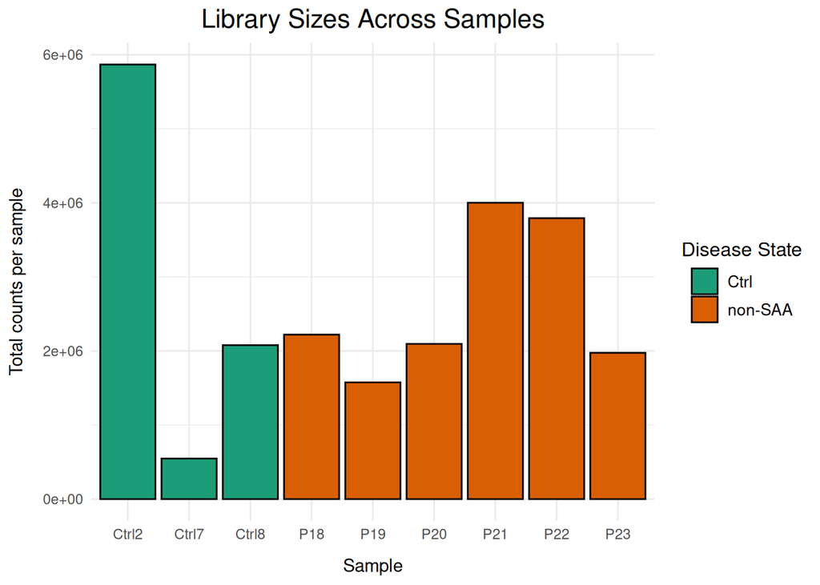

**Figure 3:** Library sizes across samples. Total counts per sample are visualized as a barplot, colored by disease state. Moderate variation is observed, with some control samples below or above the average library size, while disease samples cluster between approximately 2–4 million reads.

```r
# Compute library sizes per sample
library_sizes <- data.frame(
  sample        = metadata$sample,
  disease_state = metadata$disease_state,
  library_size  = colSums(raw_counts)
)

# Visualize library sizes as a barplot
ggplot2::ggplot(library_sizes, ggplot2::aes(x = sample, y = library_size,
                                            fill = disease_state)) +
  ggplot2::geom_bar(stat = "identity", color = "black") +
  ggplot2::scale_fill_manual(name = "Disease State", values = disease_state_colours) +
  ggplot2::ylab("Total counts per sample") +
  ggplot2::xlab("Sample") +
  ggplot2::ggtitle("Library Sizes Across Samples") +
  ggplot2::theme_minimal(base_size = 11) +
  ggplot2::theme(
    axis.title.y = ggplot2::element_text(margin = ggplot2::margin(r = 10)),
    axis.title.x = ggplot2::element_text(margin = ggplot2::margin(t = 10)),
    legend.title = ggplot2::element_text(size = 12, hjust = 0.5),
    legend.text = ggplot2::element_text(size = 10),
    plot.title = ggplot2::element_text(size = 16, hjust = 0.5)
  )
```

### 3.4.3 Detection Rate

To complement our previous measure of library quality, we will evaluate detection rate by quantifying the number of genes with non-zero counts per sample. Evaluating detection rates help identify samples with unusually low coverage or poor complexity, which could bias downstream analyses and ensure that all retained samples reliably capture the transcriptome before downstream processing and analyses (DeLuca et al. 2012). We will similarly use a barplot to visualize detection rate per sample.

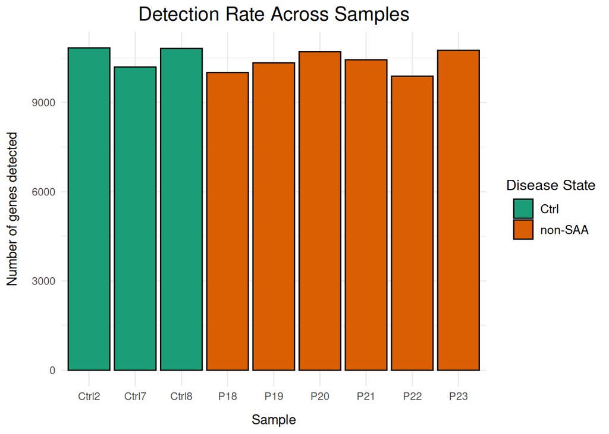

```r
# Compute detection rate: number of genes with counts > 0 per sample
detection <- data.frame(
  sample = metadata$sample,
  disease_state = metadata$disease_state,
  detected_genes = colSums(raw_counts > 0)
)

# Plot detection rate per sample
ggplot2::ggplot(detection, ggplot2::aes(x = sample, y = detected_genes,
                                           fill = disease_state)) +
  ggplot2::geom_bar(stat = "identity", color = "black") +
  ggplot2::scale_fill_manual(name = "Disease State", values = disease_state_colours) +
  ggplot2::ylab("Number of genes detected") +
  ggplot2::xlab("Sample") +
  ggplot2::ggtitle("Detection Rate Across Samples") +
  ggplot2::theme_minimal(base_size = 11) +
  ggplot2::theme(
    axis.title.y = ggplot2::element_text(margin = ggplot2::margin(r = 10)),
    axis.title.x = ggplot2::element_text(margin = ggplot2::margin(t = 10)),
    legend.title = ggplot2::element_text(size = 12, hjust = 0.5),
    legend.text = ggplot2::element_text(size = 10),
    plot.title = ggplot2::element_text(size = 16, hjust = 0.5)
  )
```

We see generally uniform gene detection per sample across both disease groups, with most samples detecting approximately 10000 genes. This consistency aligns with the library size assessment, where most samples clustered around moderate total counts, though `Ctrl2` and `Ctrl7` were flagged as potential outliers. Overall, the relatively stable detection rates suggest adequate coverage for downstream analysis, but the flagged samples should still be monitored during normalization and quality control.

### 3.4.4 Count Distribution

With lowly expressed genes already removed, examining the distribution of counts allows us to assess the remaining sample-level expression patterns, evaluate library composition, and identify any residual technical biases (DeLuca et al. 2012). We will use density plots, similar to our initial assessment when removing lowly expressed genes, to visualize the distribution of raw counts per sample.

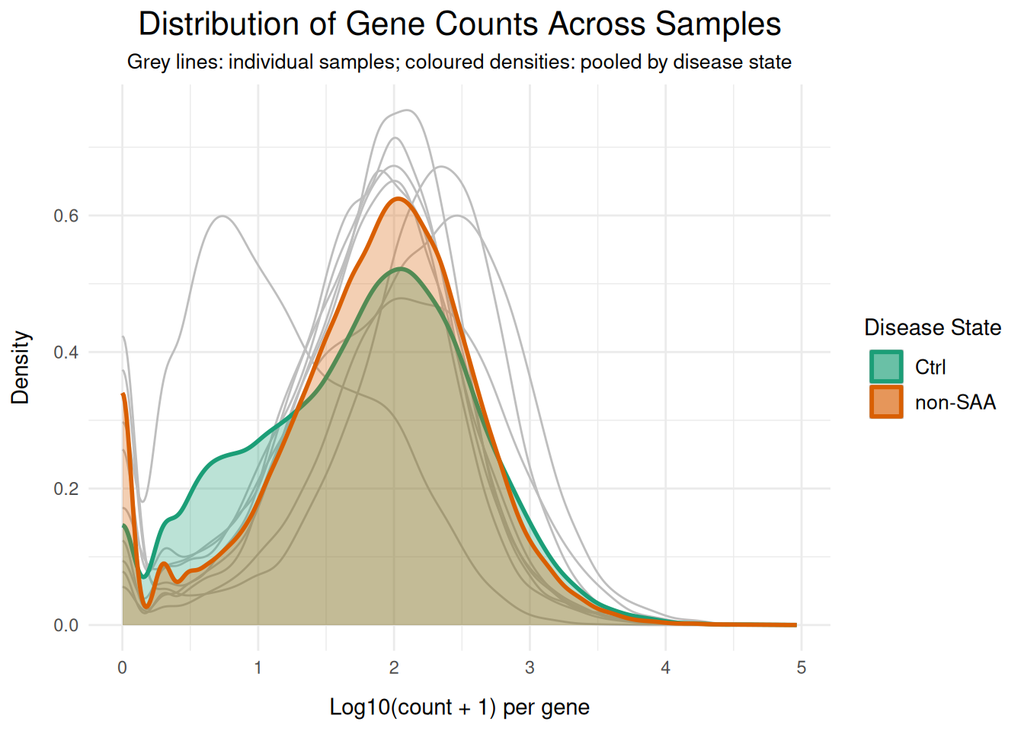

**Figure 5:** Distribution of gene counts across samples after filtering lowly expressed genes. Log10-transformed counts per gene are shown as density plots, with grey lines for individual samples and colored densities pooled by disease state. Most genes are expressed at log10(count + 1) ≈ 2, with non-SAA samples showing a slightly narrower peak and controls a broader distribution. Outlier behavior is observed in Ctrl7, with a minor secondary peak, consistent with previous library size and detection rate assessments.

```r
# Convert the raw counts to a long format for plotting
counts_long <- raw_counts %>%
  mutate(gene_id = rownames(raw_counts)) %>%
  tidyr::pivot_longer(-gene_id, names_to = "sample", values_to = "counts") %>%
  left_join(metadata[, c("sample", "disease_state")], by = "sample") %>%
  mutate(log_count = log10(counts + 1))

# Visualize the counts distribution as a density plot
ggplot2::ggplot() +
  ggplot2::geom_density(data = counts_long, color = "grey", alpha = 0.5,
                        ggplot2::aes(x = log_count, group = sample)) +
  ggplot2::geom_density(data = counts_long, alpha = 0.3, size = 1,
                        ggplot2::aes(x = log_count, color = disease_state,
                                     fill = disease_state)) +
  ggplot2::scale_color_manual(name = "Disease State", values = disease_state_colours) +
  ggplot2::scale_fill_manual(name = "Disease State", values = disease_state_colours) +
  ggplot2::xlab("Log10(count + 1) per gene") +
  ggplot2::ylab("Density") +
  ggplot2::ggtitle(
    "Distribution of Gene Counts Across Samples",
    subtitle = "Grey lines: individual samples; coloured densities: pooled by disease state") +
  ggplot2::theme_minimal(base_size = 11) +
  ggplot2::theme(
    axis.title.y = ggplot2::element_text(margin = ggplot2::margin(r = 10)),
    axis.title.x = ggplot2::element_text(margin = ggplot2::margin(t = 10)),
    legend.title = ggplot2::element_text(size = 11, hjust = 0.5),
    legend.text = ggplot2::element_text(size = 10),
    plot.title = ggplot2::element_text(size = 16, hjust = 0.5),
    plot.subtitle = ggplot2::element_text(size = 10, hjust = 0.5)
  )
```

The log10-transformed gene count distributions for control and non-SAA samples both peak near 2, indicating that most genes are expressed in this range. Non-SAA samples exhibit a slightly higher and narrower peak, whereas controls have a broader distribution with increased density near 0.5, reflecting a larger proportion of moderately expressed genes. The right-hand tail is similar across both groups, suggesting comparable representation of highly expressed genes.

Among the potential outliers previously flagged for further investigation, `Ctrl2` shows a standard distribution consistent with the group, whereas `Ctrl7` exhibits an outlier profile, with a primary peak around 0.75 and a minor secondary peak. The sample’s atypical expression patterns further suggest that it behaves as an outlier from the healthy controls and warrants further investigation.

### 3.4.5 Principal Component Analysis

Finally, we will use the `DESeq2` package to perform principal component analysis (PCA) to provide a global, unsupervised view of the dataset, summarizing major sources of variation across samples. Performing PCA prior to differential expression analysis helps identify batch effects, outliers, or unexpected clustering, ensuring that downstream analyses focus on biologically meaningful differences rather than technical artifacts (Chen et al. 2020). Specifically, PCA will allow us to investigate whether `Ctrl7` separates as a true outlier from the rest of the control samples.

[figure not shown]

```r
# Create a DESeq matrix to compute the PCA
dds <- DESeq2::DESeqDataSetFromMatrix(countData = raw_counts,
                              colData = metadata,
                              design = ~ disease_state)

# Perform a variance-stabilizing transformation
vsd <- DESeq2::vst(dds, blind = TRUE)

# Compute PCA
pca <- stats::prcomp(t(SummarizedExperiment::assay(vsd)))
percent_var <- (pca$sdev ^ 2) / sum(pca$sdev ^ 2) * 100

pca <- data.frame(PC1 = pca$x[, 1], PC2 = pca$x[, 2],
                  sample = colnames(vsd),
                  disease_state = colData(vsd)$disease_state)

# Visualize the PCA
ggplot2::ggplot(pca, ggplot2::aes(x = PC1, y = PC2, color = disease_state,
                                  label = sample)) +
  ggplot2::geom_point(size = 4, alpha = 0.8) +
  ggrepel::geom_text_repel(size = 3, nudge_y = 6) +
  ggplot2::scale_color_manual(name = "Disease State", values = disease_state_colours) +
  ggplot2::xlab(paste0("PC1: ", round(percent_var[1], 1), "% variance")) +
  ggplot2::ylab(paste0("PC2: ", round(percent_var[2], 1), "% variance")) +
  ggplot2::ggtitle("PCA of Variance-Stabilized Counts",
                    subtitle = "Pre-removal of Ctrl2 as an outlier") +
  ggplot2::theme_minimal(base_size = 11) +
  ggplot2::theme(
    plot.title = ggplot2::element_text(hjust = 0.5, size = 16),
    legend.text = ggplot2::element_text(size = 10),
    plot.subtitle = ggplot2::element_text(hjust = 0.5)
  )
```

While we should interpret clustering behaviour cautiously due to the low sample size, `Ctrl7` clearly separates along the first principal component, approximately 150 units from the main cluster at the origin, confirming its atypical expression profile. While the magnitude of this separation alone is not definitive to assign outlier status, this separation, combined with the unusual library size and distinctive count distribution previously observed, indicates that `Ctrl7` deviates from the expected sample behaviour and may represent a technical or biological outlier (Chen et al. 2020).

## 3.5 Outlier Removal

Although we only have nine total samples, including three controls, multiple quality assessments consistently indicate that `Ctrl7` behaves atypically. Removing this sample would reduce the number of control replicates to two, so the decision must be considered carefully (Schurch et al. 2016). The Zhu et al. paper did not mention any methodology regarding quality assessment results or outlier removal protocol for the bulk RNA-seq dataset, thus we will proceed with our own judgement and analysis results (Zhu et al. 2021).

```r
# Remove the technical outlier from the counts data and metadata
aa_data$Ctrl7 <- NULL
metadata <- metadata[!(metadata$sample == "Ctrl7"), ]

knitr::kable(
  head(aa_data),
  caption = "**Table 10:** Expression matrix after removal of the outlier sample `Ctrl7.` Removing this sample reduces the number of control replicates from three to two but eliminates a technical deviation consistently observed across quality assessments."
)
```

**Table 10:** Expression matrix after removal of the outlier sample `Ctrl7.` Removing this sample reduces the number of control replicates from three to two but eliminates a technical deviation consistently observed across quality assessments.

|  | gene_id | gene_symbol | Ctrl2 | Ctrl8 | P18 | P19 | P20 | P21 | P22 | P23 |
| --- | --- | --- | --- | --- | --- | --- | --- | --- | --- | --- |
| TSPAN6 | ENSG00000000003.14 | TSPAN6 | 196 | 68 | 0 | 0 | 0 | 0 | 82 | 0 |
| DPM1 | ENSG00000000419.12 | DPM1 | 684 | 123 | 34 | 103 | 116 | 421 | 67 | 123 |
| SCYL3 | ENSG00000000457.13 | SCYL3 | 48 | 52 | 1 | 23 | 22 | 69 | 33 | 13 |
| FIRRM | ENSG00000000460.16 | FIRRM | 20 | 19 | 11 | 6 | 2 | 17 | 57 | 2 |
| FGR | ENSG00000000938.12 | FGR | 163 | 29 | 71 | 24 | 101 | 38 | 0 | 114 |
| CFH | ENSG00000000971.15 | CFH | 351 | 107 | 0 | 2 | 2 | 6 | 3 | 27 |

Let us visualize the dataset using a PCA plot to confirm the results of the outlier removal.

[figure not shown]

```r
# Fetch the raw counts from the subsetted data
raw_counts <- aa_data[3:10]

# Reconstruct the DESeq2 object with the subsetted data
design <- stats::model.matrix(~ disease_state, data = metadata)
dds <- DESeq2::DESeqDataSetFromMatrix(countData = raw_counts,
                              colData = metadata,
                              design = ~ disease_state)

# Perform a variance-stabilizing transformation
vsd <- DESeq2::vst(dds, blind = TRUE)

# Compute PCA
pca <- stats::prcomp(t(SummarizedExperiment::assay(vsd)))
percent_var <- (pca$sdev ^ 2) / sum(pca$sdev ^ 2) * 100

pca <- data.frame(PC1 = pca$x[, 1], PC2 = pca$x[, 2],
                  sample = colnames(vsd),
                  disease_state = colData(vsd)$disease_state)

# Compute PCA
pca <- stats::prcomp(t(SummarizedExperiment::assay(vsd)))
percent_var <- (pca$sdev ^ 2) / sum(pca$sdev ^ 2) * 100

pca <- data.frame(PC1 = pca$x[, 1], PC2 = pca$x[, 2],
                  sample = colnames(vsd),
                  disease_state = colData(vsd)$disease_state)

# Visualize the PCA
ggplot2::ggplot(pca, ggplot2::aes(x = PC1, y = PC2, color = disease_state,
                                  label = sample)) +
  ggplot2::geom_point(size = 4, alpha = 0.8) +
  ggrepel::geom_text_repel(size = 3, nudge_y = 4) +
  ggplot2::scale_color_manual(name = "Disease State", values = disease_state_colours) +
  ggplot2::xlab(paste0("PC1: ", round(percent_var[1], 1), "% variance")) +
  ggplot2::ylab(paste0("PC2: ", round(percent_var[2], 1), "% variance")) +
  ggplot2::ggtitle("PCA of Variance-Stabilized Counts",
                   subtitle = "Post-removal of Ctrl2 as an outlier") +
  ggplot2::theme_minimal(base_size = 11) +
  ggplot2::theme(
    plot.title = ggplot2::element_text(hjust = 0.5, size = 16),
    legend.text = ggplot2::element_text(size = 10),
    plot.subtitle = ggplot2::element_text(hjust = 0.5)
  )
```

```r
# Clean up intermediate objects
rm(counts_long, dds, detection, library_sizes, pca, raw_counts, vsd, is_missing,
   is_numeric, percent_var)
```

# 4 Normalization

Normalization must be performed on the dataset to ensure that observed differences in expression reflect biological variation rather than technical artifacts (Quackenbush 2002). We will use trimmed mean of M-values (TMM) normalization because it is specifically designed for bulk RNA-seq count data (Maza 2016; Hrdlickova et al. 2016).

TMM adjusts for differences in library size and compositional biases by calculating scaling factors based on a trimmed mean of log-fold changes, which minimizes the influence of highly expressed or differentially expressed genes. This approach preserves genuine biological variation while ensuring that comparisons across samples are not confounded by technical differences (Maza 2016).

We will visualize the distribution of the counts before and after normalization to confirm that library-specific biases are mitigated and that samples are comparable for downstream differential expression analysis.

## 4.1 TMM Transformation

Let us begin by visualizing the distribution of the pre-normalized dataset using both a boxplot and a density plot. While the class material uses boxplots with outliers explicitly shown beyond the whiskers, here we overlay a violin plot, which visually represents the distribution tails and highlights extreme values in a more continuous manner.

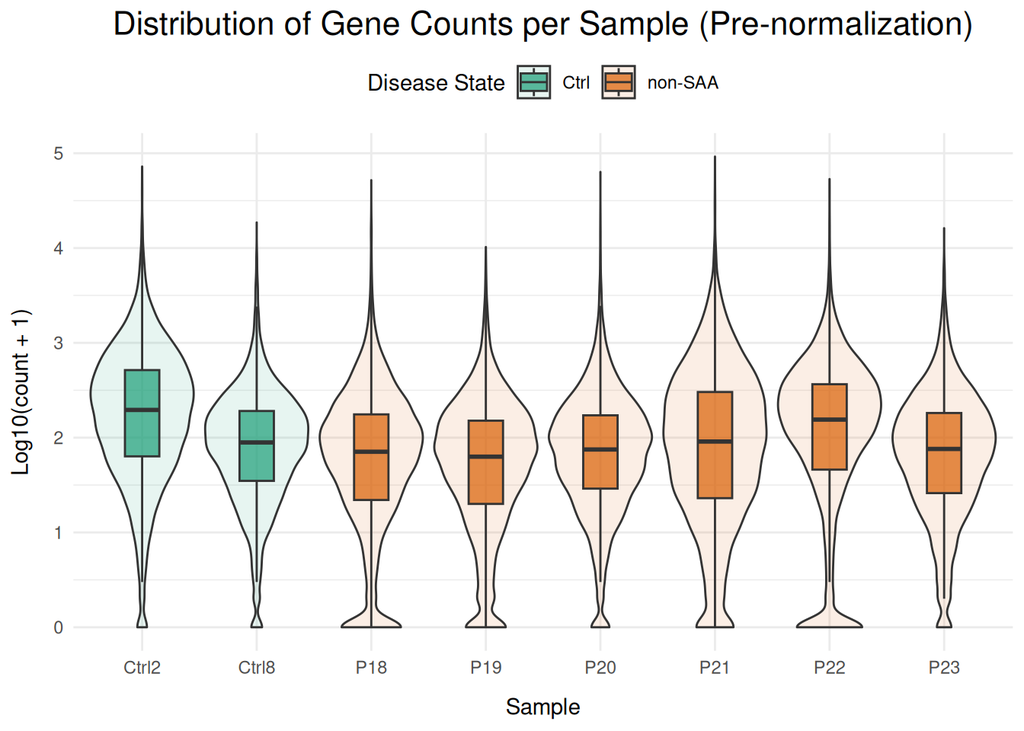

```r
# Convert the counts to a long format
counts_long <- aa_data %>%
  dplyr::select(-gene_id, -gene_symbol) %>%
  tidyr::pivot_longer(cols = everything(), names_to = "sample",
                      values_to = "count") %>%
  dplyr::mutate(disease_state = metadata$disease_state[match(sample, metadata$sample)],
                log_count = log10(count + 1))

# Visualize the distribution of counts using a boxplot
ggplot2::ggplot(counts_long, ggplot2::aes(x = sample, y = log_count, fill = disease_state)) +
  ggplot2::geom_violin(alpha = 0.1, scale = "width") +
  ggplot2::geom_boxplot(width = 0.3, alpha = 0.7, outlier.shape = NA) +
  ggplot2::scale_fill_manual(values = disease_state_colours, name = "Disease State") +
  ggplot2::xlab("Sample") +
  ggplot2::ylab("Log10(count + 1)") +
  ggplot2::ggtitle("Distribution of Gene Counts per Sample (Pre-normalization)") +
  ggplot2::theme_minimal(base_size = 11) +
  ggplot2::theme(
    axis.title.y = ggplot2::element_text(margin = ggplot2::margin(r = 10)),
    axis.title.x = ggplot2::element_text(margin = ggplot2::margin(t = 10)),
    legend.position = "top",
    plot.title = ggplot2::element_text(size = 16, hjust = 0.5)
  )
```

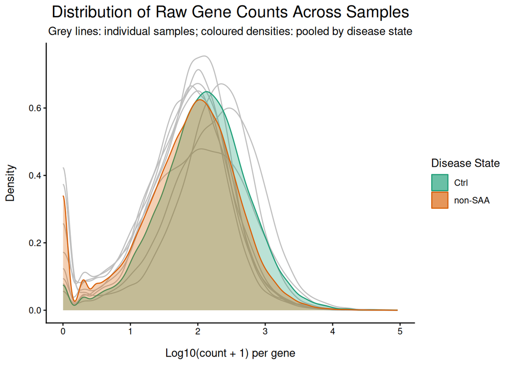

**Figure 8:** Pre-normalization distribution of gene counts across samples. (A) Violin plots overlaid with boxplots show the log10-transformed counts per sample, highlighting distribution tails and extreme values. (B) Density plots visualize the distribution of log10-transformed counts per sample, with grey lines representing individual samples and colored densities pooled by disease state.

```r
# Plot a density plot to visualize counts distribution
ggplot2::ggplot() +
  ggplot2::geom_density(data = counts_long, color = "grey", alpha = 0.5,
                        ggplot2::aes(x = log_count, group = sample)) +
  ggplot2::geom_density(data = counts_long, alpha = 0.3,
                        ggplot2::aes(x = log_count, color = disease_state,
                                     fill = disease_state)) +
  ggplot2::scale_color_manual(name = "Disease State", values = disease_state_colours) +
  ggplot2::scale_fill_manual(name = "Disease State", values = disease_state_colours) +
  ggplot2::xlab("Log10(count + 1) per gene") +
  ggplot2::ylab("Density") +
  ggplot2::ggtitle("Distribution of Raw Gene Counts Across Samples",
    subtitle = "Grey lines: individual samples; coloured densities: pooled by disease state") +
  ggplot2::theme_classic(base_size = 11) +
  ggplot2::theme(
    plot.title    = ggplot2::element_text(hjust = 0.5, size = 16),
    plot.subtitle = ggplot2::element_text(hjust = 0.5, size = 11),
    axis.title.x  = ggplot2::element_text(margin = ggplot2::margin(t = 12)),
    axis.title.y  = ggplot2::element_text(margin = ggplot2::margin(r = 12))
  )
```

We will use the `edgeR` (Chen et al. 2025) package to perform sample-based normalization using TMM. Simple library size normalization assumes that that most genes are not differentially expressed across samples, an assumption that is frequently violated in heterogeneous datasets and can bias fold-change estimates. TMM addresses this by computing a weighted, trimmed mean of log-fold changes relative to a reference sample, thereby correcting for library composition effects rather than total counts alone and enabling more accurate cross-sample comparisons (Maza 2016).

```r
# Create an edgeR object and compute the normalization factors
dge <- edgeR::DGEList(counts = aa_data, group = metadata$disease_state)
dge <- edgeR::calcNormFactors(dge, method = "TMM")

# Extract the normalized counts for inspection
normalized_counts <- data.frame(cpm(dge))

knitr::kable(
  head(normalized_counts),
  caption = "**Table 11:** First six rows of gene-level counts after TMM normalization using `edgeR`, showing adjusted expression values across all samples. Normalization accounts for library composition differences for accurate cross-sample comparison."
)
```

**Table 11:** First six rows of gene-level counts after TMM normalization using `edgeR`, showing adjusted expression values across all samples. Normalization accounts for library composition differences for accurate cross-sample comparison.

|  | Ctrl2 | Ctrl8 | P18 | P19 | P20 | P21 | P22 | P23 |
| --- | --- | --- | --- | --- | --- | --- | --- | --- |
| TSPAN6 | 33.681653 | 28.745365 | 0.0000000 | 0.000000 | 0.0000000 | 0.000000 | 19.4377788 | 0.0000000 |
| DPM1 | 117.542095 | 51.995293 | 16.5909499 | 60.496525 | 57.4195802 | 136.958440 | 15.8820875 | 57.7222439 |
| SCYL3 | 8.248568 | 21.981750 | 0.4879691 | 13.508933 | 10.8899204 | 22.446870 | 7.8225207 | 6.1007250 |
| FIRRM | 3.436903 | 8.031793 | 5.3676602 | 3.524069 | 0.9899928 | 5.530388 | 13.5116267 | 0.9385731 |
| FGR | 28.010762 | 12.259053 | 34.6458070 | 14.096278 | 49.9946345 | 12.362044 | 0.0000000 | 53.4986651 |
| CFH | 60.317654 | 45.231678 | 0.0000000 | 1.174690 | 0.9899928 | 1.951902 | 0.7111382 | 12.6707365 |

Now that the data has been TMM normalized, let’s visualize the distribution again. We expect both the boxplot–violin plot and the density plot to show improved agreement across samples. Specifically, median expression levels and overall distributional shapes should be aligned, indicating that library size and composition biases have been effectively corrected. Any remaining differences should reflect genuine biological variability rather than technical artifacts, supporting the suitability of the normalized data for downstream comparative analyses (Maza 2016).

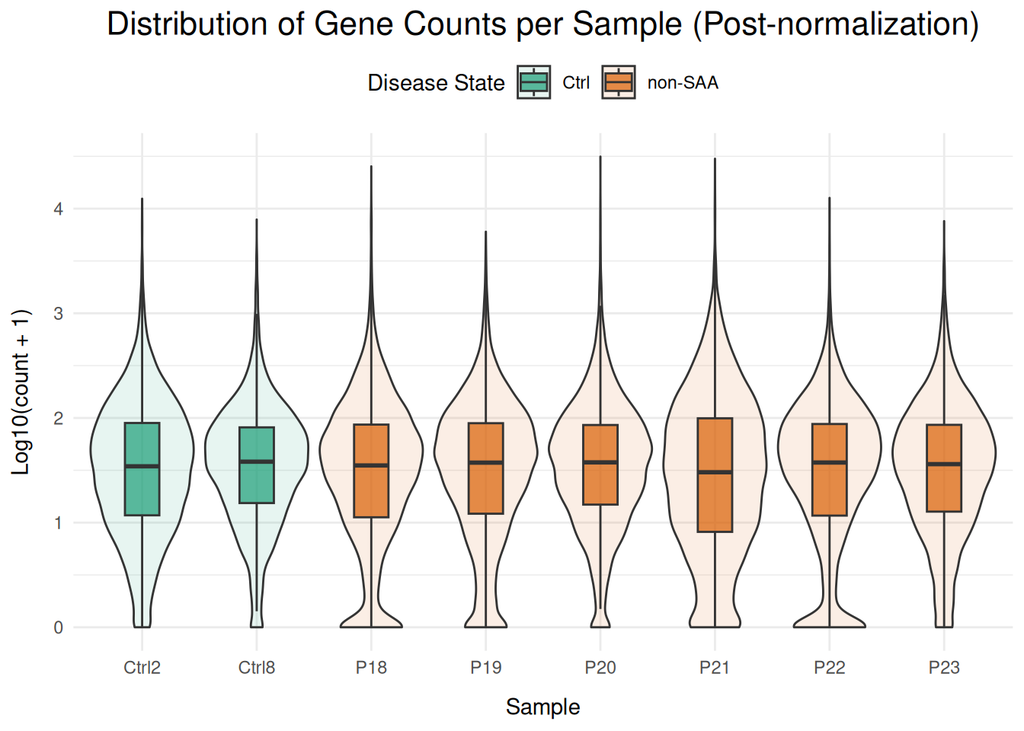

```r
# Convert the counts to a long format
normalized_long <- normalized_counts %>%
  tidyr::pivot_longer(cols = everything(), names_to = "sample",
                      values_to = "count") %>%
  dplyr::mutate(disease_state = metadata$disease_state[match(sample, metadata$sample)],
                log_count = log10(count + 1))

# Visualize the distribution of counts using a boxplot
ggplot2::ggplot(normalized_long, ggplot2::aes(x = sample, y = log_count,
                                              fill = disease_state)) +
  ggplot2::geom_violin(alpha = 0.1, scale = "width") +
  ggplot2::geom_boxplot(width = 0.3, alpha = 0.7, outlier.shape = NA) +
  ggplot2::scale_fill_manual(values = disease_state_colours, name = "Disease State") +
  ggplot2::xlab("Sample") +
  ggplot2::ylab("Log10(count + 1)") +
  ggplot2::ggtitle("Distribution of Gene Counts per Sample (Post-normalization)") +
  ggplot2::theme_minimal(base_size = 11) +
  ggplot2::theme(
    axis.title.y = ggplot2::element_text(margin = ggplot2::margin(r = 10)),
    axis.title.x = ggplot2::element_text(margin = ggplot2::margin(t = 10)),
    legend.position = "top",
    plot.title = ggplot2::element_text(size = 16, hjust = 0.5)
  )
```

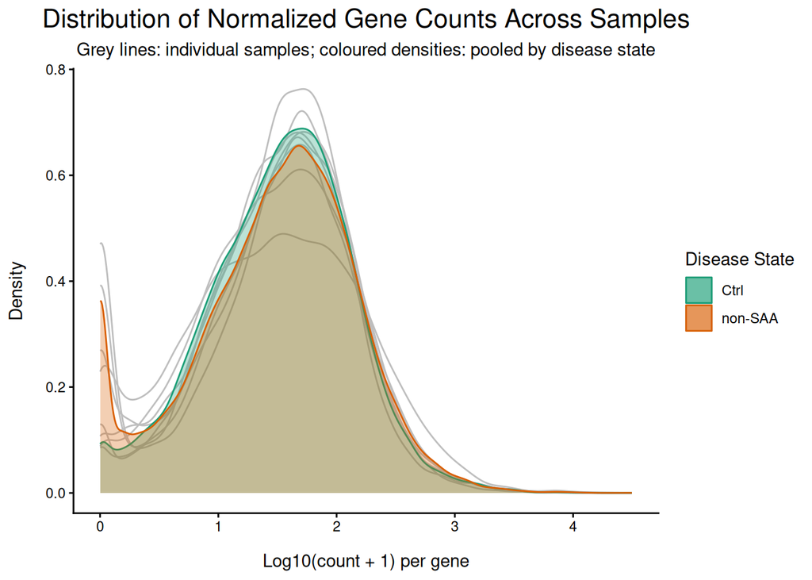

**Figure 9:** Distribution of TMM-normalized gene counts across samples (log10-transformed). (A) Boxplot–violin overlay showing median, interquartile range, and distribution tails per sample. (B) Density plot showing individual sample distributions (grey) and pooled disease state densities (coloured).

```r
# Plot a density plot to visualize counts distribution
ggplot2::ggplot() +
  ggplot2::geom_density(data = normalized_long, color = "grey", alpha = 0.5,
                        ggplot2::aes(x = log_count, group = sample)) +
  ggplot2::geom_density(data = normalized_long, alpha = 0.3,
                        ggplot2::aes(x = log_count, color = disease_state,
                                     fill = disease_state)) +
  ggplot2::scale_color_manual(name = "Disease State", values = disease_state_colours) +
  ggplot2::scale_fill_manual(name = "Disease State", values = disease_state_colours) +
  ggplot2::xlab("Log10(count + 1) per gene") +
  ggplot2::ylab("Density") +
  ggplot2::ggtitle("Distribution of Normalized Gene Counts Across Samples",
    subtitle = "Grey lines: individual samples; coloured densities: pooled by disease state") +
  ggplot2::theme_classic(base_size = 11) +
  ggplot2::theme(
    plot.title    = ggplot2::element_text(hjust = 0.5, size = 16),
    plot.subtitle = ggplot2::element_text(hjust = 0.5, size = 11),
    axis.title.x  = ggplot2::element_text(margin = ggplot2::margin(t = 12)),
    axis.title.y  = ggplot2::element_text(margin = ggplot2::margin(r = 12))
  )
```

We see that the overall shape of the count distributions within each sample is preserved, consistent with TMM acting as a sample-level scaling procedure rather than altering gene-wise relative expression. Across samples, variability is reduced, most notably in the distribution tails, where alignment improves after adjusting for library size and composition differences. A modest shift of the density peaks in log space toward a common central tendency is also observed, reflecting rescaling toward the global average; the limited magnitude of this shift is expected given that the original library sizes were not substantially different.

```r
# Remove intermediate objects
rm(counts_long, normalized_long)
```

## 4.2 Replicate Analysis

Now that the dataset has been cleaned and normalized, we next assess whether technical replicates are present. Biological replicates are intentionally kept separate to capture true variance for differential expression analysis, but any technical replicates should be resolved. This is typically done by summing counts per biological sample (Schurch et al. 2016).

As the metadata does not explicitly indicate replicates, we perform a data-driven check to identify any unusually similar or duplicated samples (Zhu et al. 2021). This analysis is done on the normalized data to reflect true biological similarity rather than differences in library size.

To do this, we generate a pairwise correlation heatmap using the 500 most variable genes, which emphasizes informative variation while reducing noise from low-expression genes.

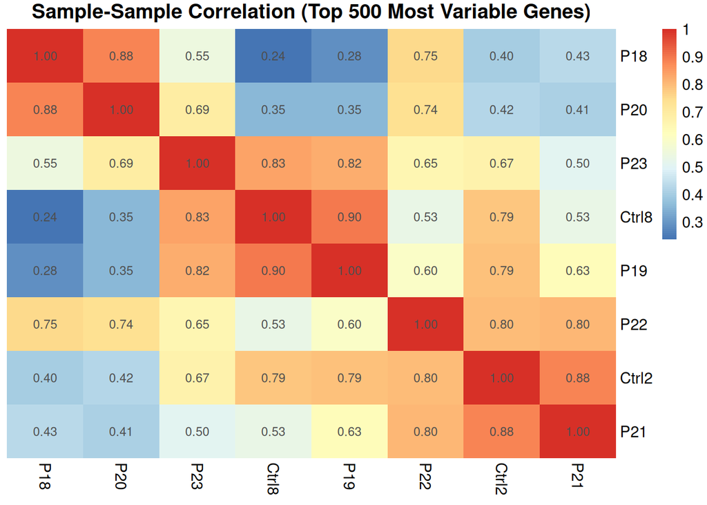

**Figure 10:** Pairwise Pearson correlation of samples based on the 500 most variable TMM-normalized genes. High correlations indicate potential technical replicates, while lower correlations reflect biological differences between samples.

```r
# Subset for the top 500 most variable genes
top_var_genes <- head(order(matrixStats::rowVars(as.matrix(normalized_counts)),
                            decreasing = TRUE), 500)

# Compute pair-wise Pearson correlations between samples
correlation <- stats::cor(normalized_counts[top_var_genes, ], method = "pearson")

# Visualize a heatmap
pheatmap::pheatmap(
  correlation,
  cluster_rows = TRUE,
  cluster_cols = TRUE,
  treeheight_row = 0,
  treeheight_col = 0,
  clustering_method = "complete",
  main = "Sample-Sample Correlation (Top 500 Most Variable Genes)",
  show_rownames = TRUE,
  show_colnames = TRUE,
  fontsize = 11,
  border_color = NA,
  display_numbers = TRUE
)
```

The sample-sample correlation heatmap reveals that the highest correlations are 0.90 (`Ctrl8` - `P19`) and 0.88 (`P18` - `P20`, `Ctrl2` - `P21`). These values are below the typical threshold (0.95-0.99) used to flag technical replicates, indicating that no hidden duplicates or unannotated replicates are present (Godoy et al. 2019).

Some moderate correlations between control and disease samples are expected given the relative homogeneity of the cell population (Lin⁻CD34⁺ bone marrow) (Young 2018). Overall, this analysis confirms that all samples are distinct, and the dataset is ready for downstream differential expression analysis.

```r
# Remove intermediate objects
rm(correlation, top_var_genes)
```

# 5 Differential Gene Expression

Now that our dataset is fully quality-controlled, normalized, and verified to contain no hidden replicates or outliers, we can proceed to differential gene expression analysis. This section will focus on identifying genes whose expression differs significantly between the defined disease and control groups.

## 5.1 Data Separation

To explore the relationship between samples prior to formal differential expression analysis, we first generate a multidimensional scaling (MDS) plot using `limma` (Ritchie et al. 2015). This approach summarizes similarities between samples based on their overall expression profiles and allows us to assess whether samples group according to biological characteristics, such as disease state (Maza 2016).

We expect that samples with similar gene expression patterns will cluster together, providing an initial visual assessment of the main sources of variation in the dataset. To evaluate which factor best explains these patterns, we will generate MDS plots coloured by disease state, sex, and age group, allowing us to compare how each factor contributes to sample clustering (Chen et al. 2020).

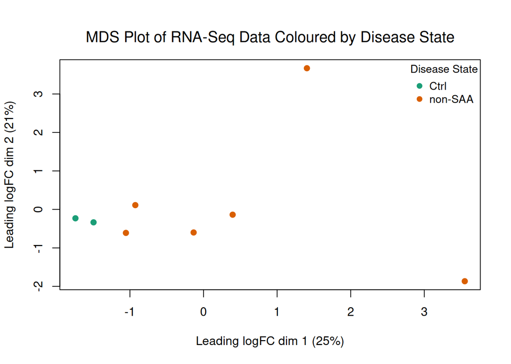

```r
# Set colour per disease state
mds_colours <- disease_state_colours[factor(metadata$disease_state)]

# Generate an MDS plot using limma
limma::plotMDS(dge, labels = NULL, pch = 19, col = mds_colours)

# Add a legend
legend(
  "topright",
  legend = levels(factor(metadata$disease_state)),
  pch = 19,
  col = disease_state_colours,
  title = "Disease State",
  bty = "n",
  cex = 0.9
)

mtext(
  "MDS Plot of RNA-Seq Data Coloured by Disease State",
  side = 3,
  line = 1,
  cex = 1.25
)
```

[figure not shown]

```r
# Define colours per sex, rather that disease state
sex_colours <- c("Male" = "#1f78b4", "Female" = "#e31a1c")
mds_colours <- sex_colours[factor(metadata$sex)]

# Generate an MDS plot using limma
limma::plotMDS(dge, labels = NULL, pch = 19, col = mds_colours)

# Add a legend
legend(
  "topright",
  legend = levels(factor(metadata$sex)),
  pch = 19,
  col = disease_state_colours,
  title = "Sex",
  bty = "n",
  cex = 0.9
)

mtext(
  "MDS Plot of RNA-Seq Data Coloured by Sex",
  side = 3,
  line = 1,
  cex = 1.25
)
```

[figure not shown]

**Figure 11:** Multidimensional scaling (MDS) of RNA-seq samples illustrating sample similarity. (A) Samples coloured by disease state, showing clear separation between controls and disease samples. (B) Samples coloured by sex, with no distinct clustering observed. (C) Samples coloured by age group, showing minimal separation. Disease state appears to be the primary factor driving sample clustering.

```r
# Create a binary age factor
metadata$age_group <- ifelse(metadata$age > 40, ">40", "≤40")

# Define colours for age groups
age_colours <- c("≤40" = "#1f78b4", ">40" = "#e31a1c")
mds_colours <- age_colours[metadata$age_group]

# Compute MDS
limma::plotMDS(dge, labels = NULL, pch = 19, col = mds_colours)

# Add a legend
legend(
  "topright",
  legend = levels(factor(metadata$age_group)),
  pch = 19,
  col = age_colours,
  title = "Age Group",
  bty = "n",
  cex = 0.9
)

mtext(
  "MDS Plot of RNA-Seq Data Coloured by Age Group",
  side = 3,
  line = 1,
  cex = 1.25
)
```

The MDS plots coloured by disease state, sex, and age group reveal that disease state provides the clearest separation between samples, with controls clustering tightly and the disease samples showing some internal heterogeneity, including two subclusters and two more distant points. Patterns based on sex or age are less distinct. However, given the small sample size, these observations should be interpreted cautiously.

Despite the within-group variability in the disease samples, disease state remains the primary biological factor of interest. The MDS plots support its inclusion in the model, as it captures the main source of variation between control and disease samples.

## 5.2 Data Variance

Next, we will use `edgeR` (Chen et al. 2025) to examine the dispersion of the dataset to assess variability in gene expression across samples. RNA-seq counts are typically modeled using a negative binomial distribution, where the dispersion parameter captures how much observed counts deviate from the mean (Maza 2016). Genes with high dispersion may reflect genuine biological variability or technical noise, and understanding this distribution is critical for accurate differential expression analysis.

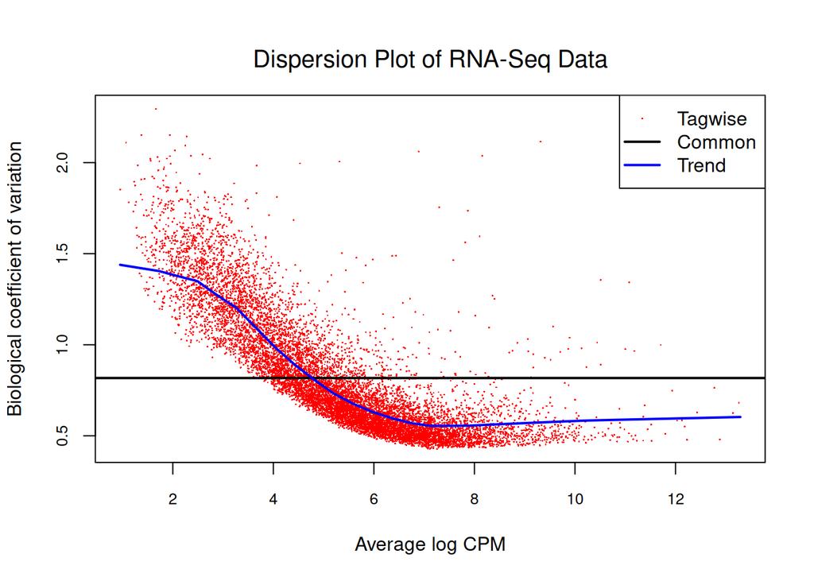

**Figure 12:** Biological coefficient of variation (BCV) plot for RNA-seq counts estimated using edgeR. The black line shows the common dispersion across all genes, while the red points represent gene-specific (tagwise) dispersions. This visualization summarizes variability across genes and informs the suitability of the negative binomial model for downstream differential expression analysis.

```r
# Estimate dispersions with edgeR
dge <- edgeR::estimateDisp(dge, design)

# Plot biological coefficient of variation (BCV)
edgeR::plotBCV(dge, col.tagwise = "red", col.common = "black", cex.lab = 1,
              cex.axis = 0.8, lwd = 1.5)

# Add a main title above the plot
mtext("Dispersion Plot of RNA-Seq Data", side = 3, line = 1, cex = 1.25)
```

No indications of technical failure or abnormal library effects are evident. With this overview of gene-level variability, we use the `edgeR` (Chen et al. 2025) package to examine the overall distribution of variance across all genes. We aim to assess whether gene-level variance scales appropriate with mean expression, as predicted by the negative binomial model.

Genes that show unusually high or low variance relative to their mean can complicate downstream differential expression analysis and reduce the accuracy of statistical inference (Conesa et al. 2016; *No Counts, No Variance*, n.d.). This mean-variance visualization provides a check that the data conforms to the assumption of negative binomial-based modeling, informing our choice in what approach we will use for differential expression analysis.

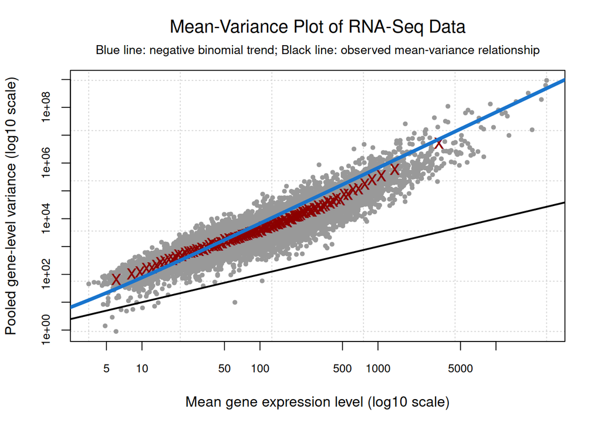

```r
# Visualize a mean-variance plot
edgeR::plotMeanVar(dge, show.raw.vars = TRUE, NBline = TRUE, cex.lab = 1,
                   cex.axis = 0.8, pch = 19)

# Add a main title above the plot
mtext("Mean-Variance Plot of RNA-Seq Data", side = 3, line = 2, cex = 1.25)

# Add a subtitle below the plot
mtext("Blue line: negative binomial trend; Black line: observed mean-variance relationship",
      side = 3, line = 0.75, cex = 0.85)
```

The mean-variance plot indicates that gene-level variance in our dataset closely follows the expected negative binomial relationship. Based on this, we will proceed with differential expression analysis using `edgeR` (Chen et al. 2025), which models counts under a negative binomial framework.

## 5.3 Differential Analysis

We will use the `edgeR` (Chen et al. 2025) package to perform differential gene expression analysis to identify genes whose expression differs between disease and control samples. This analysis uses a negative binomial model to account for count variability across samples.

```r
# Fit the data dispersion to the model and test for DE on the disease state
fit <- edgeR::glmQLFit(dge, design)
qlf <- edgeR::glmQLFTest(fit, coef = "disease_statenon-SAA")

# Retrieve the top hits by p-value
top_hits <- edgeR::topTags(qlf, sort.by = "PValue", n = nrow(normalized_counts))
top_hits <- as.data.frame(top_hits$table)
top_hits$gene_symbol <- rownames(top_hits)

knitr::kable(
  head(top_hits),
  caption = "**Table 12:** Top differentially expressed genes identified using `edgeR.` Columns include log2 fold change, raw and adjusted p-values, and gene symbols. Genes are ranked by ascending p-value."
)
```

**Table 12:** Top differentially expressed genes identified using `edgeR.` Columns include log2 fold change, raw and adjusted p-values, and gene symbols. Genes are ranked by ascending p-value.

|  | gene_id | gene_symbol | logFC | logCPM | F | PValue | FDR |
| --- | --- | --- | --- | --- | --- | --- | --- |
| MYCT1 | ENSG00000120279.6 | MYCT1 | -5.549074 | 5.503509 | 55.02337 | 1.00e-07 | 0.0015118 |
| C3orf80 | ENSG00000180044.5 | C3orf80 | -5.180615 | 4.178397 | 38.15200 | 1.40e-06 | 0.0076881 |
| EREG | ENSG00000124882.3 | EREG | -3.110972 | 7.347129 | 46.32838 | 2.10e-06 | 0.0076881 |
| CXCL2 | ENSG00000081041.8 | CXCL2 | -4.197923 | 6.010751 | 42.82119 | 3.00e-06 | 0.0083700 |
| HLF | ENSG00000108924.13 | HLF | -11.060942 | 4.565164 | 56.32877 | 3.90e-06 | 0.0085911 |
| ST6GAL2 | ENSG00000144057.15 | ST6GAL2 | -5.854468 | 4.406744 | 29.25063 | 1.18e-05 | 0.0215475 |

Next, we will filter differentially expressed genes using a p-value threshold of 0.05 to identify statistically significant changes. This threshold represents the conventional cutoff for significance in gene expression studies (*Thresholding of Statistical Maps in Functional Neuroimaging Using the False Discovery Rate - ScienceDirect*, n.d.).

```r
dim(top_hits[top_hits$PValue < 0.05, ])
```

```
## [1] 819   7
```

Using the p-value threshold, we identify 819 significantly differentially expressed genes in our dataset.

## 5.4 Multiple Hypothesis Testing

To account for multiple testing and control the false discovery rate, we use the FDR values already returned by `edgeR` (Chen et al. 2025), which apply the Benjamini–Hochberg (BH) correction (Benjamini and Hochberg 1995). Genes are considered significant if they meet a threshold of 0.05 for both the FDR and nominal p-value, a standard approach to limit false positives while retaining biologically meaningful signals (Mascha and Vetter 2018).

```r
knitr::kable(
  top_hits[top_hits$FDR < 0.05 & top_hits$PValue < 0.05, ],
  caption = "**Table 12:** Differentially expressed genes with both nominal p-value < 0.05 and FDR < 0.05, indicating statistically significant changes between disease and control samples. Columns include log2 fold change, p-value, FDR, and gene symbol."
)
```

**Table 12:** Differentially expressed genes with both nominal p-value < 0.05 and FDR < 0.05, indicating statistically significant changes between disease and control samples. Columns include log2 fold change, p-value, FDR, and gene symbol.

|  | gene_id | gene_symbol | logFC | logCPM | F | PValue | FDR |
| --- | --- | --- | --- | --- | --- | --- | --- |
| MYCT1 | ENSG00000120279.6 | MYCT1 | -5.549074 | 5.503509 | 55.02337 | 1.00e-07 | 0.0015118 |
| C3orf80 | ENSG00000180044.5 | C3orf80 | -5.180615 | 4.178397 | 38.15200 | 1.40e-06 | 0.0076881 |
| EREG | ENSG00000124882.3 | EREG | -3.110972 | 7.347129 | 46.32838 | 2.10e-06 | 0.0076881 |
| CXCL2 | ENSG00000081041.8 | CXCL2 | -4.197923 | 6.010751 | 42.82119 | 3.00e-06 | 0.0083700 |
| HLF | ENSG00000108924.13 | HLF | -11.060942 | 4.565164 | 56.32877 | 3.90e-06 | 0.0085911 |
| ST6GAL2 | ENSG00000144057.15 | ST6GAL2 | -5.854468 | 4.406744 | 29.25063 | 1.18e-05 | 0.0215475 |
| PREX2 | ENSG00000046889.18 | PREX2 | -5.162116 | 3.714621 | 27.60423 | 1.83e-05 | 0.0287653 |
| CRHBP | ENSG00000145708.10 | CRHBP | -3.375625 | 6.110685 | 32.12857 | 2.10e-05 | 0.0287915 |

After applying both the p-value and FDR thresholds, eight genes remain significantly differentially expressed. Given the small sample size and moderate dispersion observed in this dataset, the Benjamini–Hochberg correction is stringent, so obtaining a single-digit number of significant genes is expected (Benjamini and Hochberg 1995; Conesa et al. 2016).

### 5.4.1 Volcano Plot

First, we will visualize the significantly differentially expressed genes using a volcano plot. This plot allows us to simultaneously assess up- and down-regulated genes relative to their log-fold changes and significance thresholds (p-value and BH-adjusted FDR), highlighting genes of interest that meet these criteria.

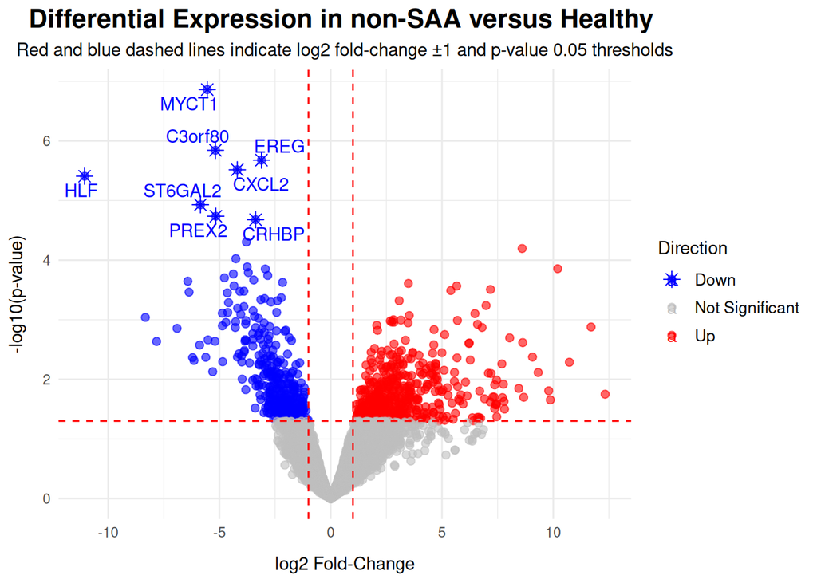

**Figure 14:** Volcano plot of differential expression results comparing non-SAA versus healthy samples. Points are coloured by significance and direction: red = upregulated, blue = downregulated, grey = not significant. Dashed red lines indicate log2 fold-change ±1 and nominal p-value 0.05 thresholds. Genes passing FDR < 0.05 are labelled.

```r
# Categorize whether a gene is differentially expressed or not by p-value
top_hits$direction <- "Not Significant"
top_hits$direction[top_hits$logFC > 1.0 & top_hits$PValue < 0.05] <- "Up"
top_hits$direction[top_hits$logFC < -1.0 & top_hits$PValue < 0.05] <- "Down"

# Label genes that pass BH correction
top_hits$label <- NA
top_hits$label[top_hits$FDR < 0.05] <- top_hits$gene_symbol[top_hits$FDR < 0.05]

# Plot a volcano plot with all annotations
ggplot2::ggplot(top_hits, ggplot2::aes(x = logFC, y = -log10(PValue),
                                       col = direction)) +
  ggplot2::geom_point(alpha = 0.6, size = 2) +
  ggplot2::geom_point(data = subset(top_hits, !is.na(label)), shape = 8,
                      size = 3) +
  ggrepel::geom_text_repel(ggplot2::aes(label = label), max.overlaps = 10) +
  ggplot2::scale_color_manual(values = c("Up" = "red", "Down" = "blue",
                                         "Not Significant" = "grey")) +
  ggplot2::geom_vline(xintercept = c(-1.0, 1.0), col = "red",
                      linetype = "dashed") +
  ggplot2::geom_hline(yintercept = -log10(0.05), col = "red",
                      linetype = "dashed") +
  ggplot2::theme_minimal() +
  ggplot2::labs(
    title = "Differential Expression in non-SAA versus Healthy ",
    subtitle = "Red and blue dashed lines indicate log2 fold-change ±1 and p-value 0.05 thresholds",
    x = "log2 Fold-Change",
    y = "-log10(p-value)",
    color = "Direction"
  ) +
  ggplot2::theme_minimal(base_size = 11) +
  ggplot2::theme(
    plot.title = ggplot2::element_text(hjust = 0.5, size = 16, face = "bold"),
    plot.subtitle = ggplot2::element_text(hjust = 0.5, size = 11),
    axis.title.x = ggplot2::element_text(margin = ggplot2::margin(t = 10)),
    axis.title.y = ggplot2::element_text(margin = ggplot2::margin(r = 10)),
    legend.title = ggplot2::element_text(size = 11),
    legend.text = ggplot2::element_text(size = 10)
  )
```

Among the FDR-significant genes, all eight are downregulated, suggesting a consistent repression in the disease state relative to controls. However, this observation should be interpreted cautiously, as the small sample size limits statistical power and the generalizability of these results.

### 5.4.2 Heatmap

Next, we will visualize the top differentially expressed genes using a heatmap to assess how these genes separate samples by disease state. To provide a more informative view, we include all genes with p-value < 0.05, rather than restricting to the FDR-significant genes, which are very few.

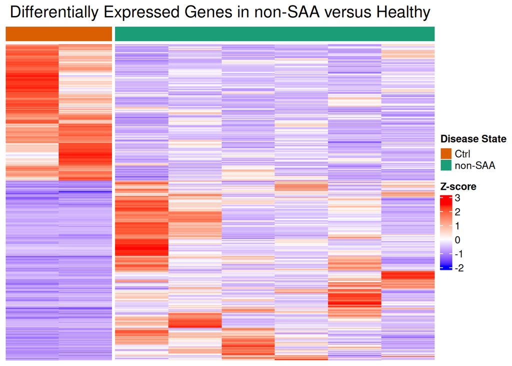

**Figure 15:** Heatmap of genes with p-value < 0.05 from differential expression analysis comparing non-SAA versus healthy samples. Rows represent genes (row-scaled as Z-scores) and columns represent samples, split and annotated by disease state. Blue indicates lower expression, red higher expression relative to the row mean.

```r
# Extract results that pass the p-value threshold
pval_hits <- rownames(top_hits[top_hits$PValue < 0.05, ])

# Fetch the normalized counts of all p-value significant hits
pval_counts <- normalized_counts[which(rownames(normalized_counts) %in% pval_hits), ]

# Row-normalize the data
heatmap_top_hits <- t(scale(t(pval_counts)))

# Create a colour mapping for disease state
heatmap_col = circlize::colorRamp2(c(min(heatmap_top_hits), 0, max(heatmap_top_hits)),
                                   c("blue", "white", "red"))
state_colours <- c("non-SAA" = "#1b9e77", "Ctrl" = "#d95f02")

# Align the metadata to the heatmap columns
disease_vec <- metadata[colnames(heatmap_top_hits), "disease_state"]
names(disease_vec) <- colnames(heatmap_top_hits)

# Annotate by disease state
annotation <- ComplexHeatmap::HeatmapAnnotation(
  disease_type = disease_vec,
  col = list(disease_type = state_colours),
  show_legend = TRUE,
  show_annotation_name = FALSE,
  annotation_legend_param = list(
    disease_type = list(
      title = "Disease State"
    ))
)

ht <- ComplexHeatmap::Heatmap(
  as.matrix(heatmap_top_hits),
  name = "Z-score",
  col = heatmap_col,
  top_annotation = annotation,
  column_split = disease_vec,
  cluster_rows = TRUE, cluster_columns = TRUE,
  show_row_dend = FALSE, show_column_dend = FALSE,
  show_column_names = FALSE, show_row_names = FALSE,
  heatmap_legend_param = list(title = "Z-score"),
  column_title = "Differentially Expressed Genes in non-SAA versus Healthy",
  column_title_gp = grid::gpar(fontsize = 16)
)

# Plot the heatmap; this will throw 'plot.first' warnings when knitting,
# but they are benign; happens because we're knitting to HTML and not PDF
ComplexHeatmap::draw(ht, merge_legend = TRUE)
```

The heatmap reveals clear condition-associated clustering, with control samples clustering tightly together, indicating high internal consistency and concordant expression patterns across differentially expressed genes. Approximately half of the genes exhibit relatively higher expression in controls, accompanied by uniform but modest repression in disease samples with consistent direction but limited effect sizes.

In contrast, disease samples display greater heterogeneity, forming subgroups rather than a single compact cluster, with the remaining genes showing mixed directions of expression change, likely reflecting biological heterogeneity. However, given the small sample size, these observations are inherently limited and cannot be considered definitive, as reduced statistical power may accentuate apparent variability and constrain robust inference.

```r
# Clean all objects
rm(annotation, correlation, heatmap_top_hits, legend, pval_counts, qlf, top_hits,
   age_group, disease_state_colours, disease_vec, mds_colours, pval_hits,
   sex_colours, state_colours, top_var_genes, heatmap_col, age_colours,
   normalized_counts, fit, aa_data, design, dge, metadata, ht)
gc()
```

```
##            used  (Mb) gc trigger  (Mb) max used  (Mb)
## Ncells  9453755 504.9   14104754 753.3 14104754 753.3
## Vcells 16971516 129.5   31214951 238.2 31214950 238.2
```

# 6 Conclusion

# 7 Question Key

**What are the control and test conditions of the dataset?**

The test condition is patients with non-severe aplastic anemia (non-SAA) and the control condition is healthy donors.

**How many samples are in each of the conditions of your dataset?**

The dataset includes three control and six non-SAA samples for a total of nine. However, one control sample was removed as an outlier, thus two controls and six non-SAA samples for a total of eight samples were effectively used in this analysis.

**Were there expression values that were not unique for specific genes? How did you handle these?**

No, there were no duplicate expression values that were not unique for specific genes. In other words, no HGNC symbol mapped to more than one Ensembl gene identifier.

**Were there expression values that could not be mapped to current HUGO symbols?**

Yes, 27 Ensembl gene identifiers could not be mapped to HGNC symbols. This is because they were deprecated in the most recent database release. As per the course discussion board, their symbols were left as `NA`.

**Were there any outliers in your dataset? How were they handled in the originating paper? How many outliers were removed?**

The originating paper did not mention how outliers were handled. In this analysis, one outlier was identified and removed. Please refer to the corresponding section for the full evidence and validation of this choice.

**How did you handle replicates?**

No replicates were found in the dataset after investigation.

**What is the final coverage of your dataset?**

The final coverage of the dataset is `10984` genes across eight samples.

**Calculate p-values for each of the genes in your expression set. How many genes were significantly differentially expressed? What thresholds did you use and why?**

The dataset has 819 genes that are significantly differentially expressed. A threshold of p-value < 0.05 was used as it is the conventional cutoff for significance in gene expression studies.

**Multiple hypothesis testing - correct your p-values using a multiple hypothesis correction method. Which method did you use? And Why? How many genes passed correction?**

The dataset has eight significantly differentially expressed genes that passed correction. The Benjamini-Hochberg (BH) method was used to account for multiple testing and control the false discovery rate, maintaining statistical power while still correcting for multiplicity. Furthermore, FDR values are already returned by `edgeR`.

**Show the amount of differentially expressed genes using an MA Plot or a Volcano plot. Highlight genes of interest.**

Please refer to the linked section for the corresponding figure.

**Visualize your top hits using a heatmap. Do the conditions cluster together? Explain why or why not.**

Please refer to the linked section for the corresponding figure.

Yes, the conditions cluster together. Control samples cluster tightly together, indicating high internal consistency and similar expression patterns across the differentially expressed genes. In contrast, disease samples do not form a single compact cluster but instead split into subgroups, reflecting greater heterogeneity. This increased variability is likely biological in origin, though the small sample size limits statistical power and may exaggerate apparent heterogeneity, preventing definitive conclusions.

# References

Barrett, Tanya, Stephen E. Wilhite, Pierre Ledoux, et al. 2013. “NCBI GEO: Archive for Functional Genomics Data Sets—Update.” *Nucleic Acids Research* 41 (D1): D991–95. https://doi.org/10.1093/nar/gks1193.

Benjamini, Yoav, and Yosef Hochberg. 1995. “Controlling the False Discovery Rate: A Practical and Powerful Approach to Multiple Testing.” *Journal of the Royal Statistical Society* 57: 289–300.

Chen, Xiaoying, Bo Zhang, Ting Wang, Azad Bonni, and Guoyan Zhao. 2020. “Robust Principal Component Analysis for Accurate Outlier Sample Detection in RNA-Seq Data.” *BMC Bioinformatics* 21 (1): 269. https://doi.org/10.1186/s12859-020-03608-0.

Chen, Yunshun, Lizhong Chen, Aaron T. L. Lun, Pedro Baldoni, and Gordon K. Smyth. 2025. “edgeR V4: Powerful Differential Analysis of Sequencing Data with Expanded Functionality and Improved Support for Small Counts and Larger Datasets.” *Nucleic Acids Research* 53 (2): gkaf018. https://doi.org/10.1093/nar/gkaf018.

Conesa, Ana, Pedro Madrigal, Sonia Tarazona, et al. 2016. “A Survey of Best Practices for RNA-Seq Data Analysis.” *Genome Biology* 17 (1): 13. https://doi.org/10.1186/s13059-016-0881-8.

Davis, Sean, and Paul Meltzer. 2007. “GEOquery: A Bridge Between the Gene Expression Omnibus (GEO) and BioConductor.” *Bioinformatics* 14: 1846–47. https://doi.org/10.1093/bioinformatics/btm254.

DeLuca, David S., Joshua Z. Levin, Andrey Sivachenko, et al. 2012. “RNA-SeQC: RNA-Seq Metrics for Quality Control and Process Optimization.” *Bioinformatics* 28 (11): 1530–32. https://doi.org/10.1093/bioinformatics/bts196.

Durinck, Steffen, Yves Moreau, Arek Kasprzyk, et al. 2005. “BioMart and Bioconductor: A Powerful Link Between Biological Databases and Microarray Data Analysis.” *Bioinformatics* 21: 3439–40.

Durinck, Steffen, Paul T. Spellman, Ewan Birney, and Wolfgang Huber. 2009. “Mapping Identifiers for the Integration of Genomic Datasets with the R/Bioconductor Package biomaRt.” *Nature Protocols* 4: 1184–91.

Godoy, Paula, Andrea Barczak, Peter DeHolf, et al. 2019. “Comparison of Reproducibility, Accuracy, Sensitivity, and Specificity of miRNA Quantification Platforms.” *Cell Rep* 29: 4212–22.

Gu, Zuguang, Roland Eils, and Matthias Schlesner. 2016. “Complex Heatmaps Reveal Patterns and Correlations in Multidimensional Genomic Data.” *Bioinformatics*, ahead of print. https://doi.org/10.1093/bioinformatics/btw313.

Gu, Zuguang, Lei Gu, Roland Eils, Matthias Schlesner, and Benedikt Brors. 2014. “Circlize Implements and Enhances Circular Visualization in r.” *Bioinformatics*, ahead of print. https://doi.org/10.1093/bioinformatics/btu393.

Hrdlickova, Radmila, Masoud Toloue, and Bin Tian. 2016. “RNA‐Seq Methods for Transcriptome Analysis - Hrdlickova - 2017 - WIREs RNA - Wiley Online Library.” In *Advanced Review*, vol. 8. https://doi.org/https://doi.org/10.1002/wrna.1364.

Isserlin, Ruth. 2026. *BCB420: Computational Systems Biology Lectures*.

Kolde, Raivo. 2025. *Pheatmap: Pretty Heatmaps*.

Lamarre, Sophie, Pierre Frasse, Mohamed Zouine, et al. 2018. “Optimization of an RNA-Seq Differential Gene Expression Analysis Depending on Biological Replicate Number and Library Size.” *Frontiers in Plant Science* 9 (February). https://doi.org/10.3389/fpls.2018.00108.

Love, Michael I., Wolfgang Huber, and Simon Anders. 2014. “Moderated Estimation of Fold Change and Dispersion for RNA-Seq Data with DESeq2.” *Genome Biology* 15 (12): 550. https://doi.org/10.1186/s13059-014-0550-8.

Mascha, Edward J., and Thomas R. Vetter. 2018. “Significance, Errors, Power, and Sample Size: The Blocking and Tackling of Statistics.” *Anesthesia & Analgesia* 126 (2): 691. https://doi.org/10.1213/ANE.0000000000002741.

Maza, Elie. 2016. “In Papyro Comparison of TMM (edgeR), RLE (DESeq2), and MRN Normalization Methods for a Simple Two-Conditions-Without-Replicates RNA-Seq Experimental Design.” *Frontiers in Genetics* 7 (September). https://doi.org/10.3389/fgene.2016.00164.

Morgan, Martin, Valerie Obenchain, Jim Hester, and Hervé Pagès. 2025. *SummarizedExperiment: A Container (S4 Class) for Matrix-Like Assays*. https://doi.org/10.18129/B9.bioc.SummarizedExperiment.

Neuwirth, Erich. 2022. *RColorBrewer: ColorBrewer Palettes*. https://doi.org/10.32614/CRAN.package.RColorBrewer.

*No Counts, No Variance: Allowing for Loss of Degrees of f...* n.d. Accessed February 10, 2026. https://www.degruyterbrill.com/document/doi/10.1515/sagmb-2017-0010/html.

Povey, Sue, Ruth Lovering, Elspeth Bruford, Mathew Wright, Michael Lush, and Hester Wain. 2001. “The HUGO Gene Nomenclature Committee (HGNC).” *Human Genetics* 109 (6): 678–80. https://doi.org/10.1007/s00439-001-0615-0.

Quackenbush, John. 2002. “Microarray Data Normalization and Transformation.” *Nature Genetics* 32 (4): 496–501. https://doi.org/10.1038/ng1032.

Ritchie, Matthew E., Belinda Phipson, Di Wu, et al. 2015. “Limma Powers Differential Expression Analyses for RNA-Sequencing and Microarray Studies.” *Nucleic Acids Research* 43 (7): e47. https://doi.org/10.1093/nar/gkv007.

Schurch, Nicholas J., Pietá Schofield, Marek Gierliński, et al. 2016. “How Many Biological Replicates Are Needed in an RNA-Seq Experiment and Which Differential Expression Tool Should You Use?” *RNA* 22 (6): 839–51. https://doi.org/10.1261/rna.053959.115.

Sha, Ying, John H. Phan, and May D. Wang. 2015b. “Effect of Low-Expression Gene Filtering on Detection of Differentially Expressed Genes in RNA-Seq Data.” *2015 37th Annual International Conference of the IEEE Engineering in Medicine and Biology Society (EMBC)*, August, 6461–64. https://doi.org/10.1109/EMBC.2015.7319872.

Sha, Ying, John H. Phan, and May D. Wang. 2015a. “Effect of Low-Expression Gene Filtering on Detection of Differentially Expressed Genes in RNA-Seq Data.” *2015 37th Annual International Conference of the IEEE Engineering in Medicine and Biology Society (EMBC)*, August, 6461–64. https://doi.org/10.1109/EMBC.2015.7319872.

Slowikowski, Kamil. 2024. *Ggrepel: Automatically Position Non-Overlapping Text Labels with ’Ggplot2’*. https://doi.org/10.32614/CRAN.package.ggrepel.

*Thresholding of Statistical Maps in Functional Neuroimaging Using the False Discovery Rate - ScienceDirect*. n.d. Accessed February 10, 2026. https://www.sciencedirect.com/science/article/abs/pii/S1053811901910377?via%3Dihub.

Wickham, Hadley. 2016. *Ggplot2: Elegant Graphics for Data Analysis*. Springer-Verlag New York. https://ggplot2.tidyverse.org.

Wickham, Hadley. 2025. *Stringr: Simple, Consistent Wrappers for Common String Operations*. https://stringr.tidyverse.org.

Wickham, Hadley, Romain François, Lionel Henry, Kirill Müller, and Davis Vaughan. 2023. *Dplyr: A Grammar of Data Manipulation*. https://doi.org/10.32614/CRAN.package.dplyr.

Wickham, Hadley, Davis Vaughan, and Maximilian Girlich. 2024. *Tidyr: Tidy Messy Data*. https://doi.org/10.32614/CRAN.package.tidyr.

Xie, Yihui. 2014. “Knitr: A Comprehensive Tool for Reproducible Research in R.” In *Implementing Reproducible Computational Research*, edited by Victoria Stodden, Friedrich Leisch, and Roger D. Peng. Chapman; Hall/CRC.

Yates, Andrew D, Olanrewaju Austine-Orimoloye, Andrey G Azov, et al. 2026. “Ensembl 2026.” *Nucleic Acids Research* 54 (D1): D1053–60. https://doi.org/10.1093/nar/gkaf1239.

Young, Neal S. 2018. “Aplastic Anemia.” *New England Journal of Medicine* 379 (17): 1643–56. https://doi.org/10.1056/NEJMra1413485.

Zhu, Caiying, Yu Lian, Chenchen Wang, et al. 2021. “Single-Cell Transcriptomics Dissects Hematopoietic Cell Destruction and T-Cell Engagement in Aplastic Anemia.” *Blood* 138 (1): 23–33. https://doi.org/10.1182/blood.2020008966.